# Basics of python programming for Pharmaceutical sciences

# Installing Third-Party Libraries

```python
# pip is the Python package installer
# Run these commands in your Google collaborator:
#please note that if you run in Google collab- every command will take '!' before the pip and if you are doing it on your local machine then just uncomment the necesary
#install commands
# uncomment the necessary install command below based on your needs

# Install a single library:
# we want to install pandas - so we will use the below pip install command
!pip install pandas

# Install multiple libraries at once:
# pip install numpy pandas matplotlib seaborn

# Install a specific version:
# pip install pandas==2.0.3

# Check what's installed:
# pip list

# Uninstall a library you no longer need:
# pip uninstall pandas

# In Google Colab, use ! before pip:
# !pip install rdkit-pypi     # For molecular analysis
# !pip install bioPython      # For DNA/protein sequences

# Import a library in your code:
import numpy as np            # 'np' is a short alias (nickname)
import pandas as pd           # 'pd' is a short alias
import matplotlib.pyplot as plt  # 'plt' is a short alias
```

**Basic If statement in Python**

```python
body_temp=input('Enter body temperature: ')
body_temp=float(body_temp)
if body_temp>100.4:
   print('patient has fever & doctor consultation is necessary')
```

```
Enter body temperature: 110
patient has fever & doctor consultation is necessary
```

**Sample Conditional Checks using 'if' statement**

```python
# if statement — executes only when condition is True
# Syntax:
#   if condition:
#       code to run (indented by 4 spaces or 1 Tab)

# Example: Check if dose is within safe limit
dose_mg = 750
dose_mg_2 = float(input('Enter dose in mg: ')) # system blocks for the user input & based on the inputted numeric values -condition checks happen
#try entering some text as input & see what happens - you should get error as text can't be converted in to float values
max_safe_dose = 1000  # mg per dose (e.g., Paracetamol)

if dose_mg > max_safe_dose: #pay attention to key words if and : at the end
# the following two print statements need to be executed if the above condition is true
    print('WARNING: Dose exceeds safe limit!') # pay attention to the indentation
    print('Reduce dose or consult prescriber.') # pay attention to the indentation

if dose_mg_2 > max_safe_dose: #pay attention to key words if and : at the end
# the following two print statements need to be executed if the above condition is true
    print('WARNING: Dose_2 exceeds safe limit!') # pay attention to the indentation
    print('Reduce dose or consult prescriber.') # pay attention to the indentation

# If dose_mg = 750, this block does NOT execute (750 is not > 1000)
# If dose_mg = 1200, both print statements would run
```

```
Enter dose in mg: 900
```

**if-else sample code** - Determine safe temperature to stroe drugs

```python
# if-else — does one thing if True, another if False
# Syntax:
#   if condition:
#       code when True
#   else:
#       code when False

# Example: Drug Storage Temperature Check
storage_temp = 28  # degrees Celsius
max_temp = 25      # recommended maximum

if storage_temp <= max_temp:
    print('Storage conditions: ACCEPTABLE')
    print(f'Temperature {storage_temp}°C is within the safe range.')
else:
    print('Storage conditions: UNACCEPTABLE!')
    print(f'Temperature {storage_temp}°C exceeds {max_temp}°C limit.')
    print('Action: Move drug to refrigerator immediately.')

# Output:
# Storage conditions: UNACCEPTABLE!
# Temperature 28°C exceeds 25°C limit.
# Action: Move drug to refrigerator immediately.
```

```
Storage conditions: UNACCEPTABLE!
Temperature 28°C exceeds 25°C limit.
Action: Move drug to refrigerator immediately.
```

**if -else- multipe conditions check- example code**

```python
# if-elif-else — handles multiple conditions
# Syntax:
#   if condition1:
#       code block 1
#   elif condition2:
#       code block 2
#   elif condition3:
#       code block 3
#   else:
#       default code block

# Example: Paracetamol Dose Recommendation Based on Age Group
#The line below will open a user input dialogue so that user can enter patient age #dynamically at run time
#pay attention to the casting being done once the user input is entered. if you #enter non-numeric values, this below line will throw an error

age = int(input('Enter patient age: '))

if age < 1:
    print('Consult paediatrician — not recommended under 1 year')
elif age >= 1 and age <= 5:
    dose = 120  # mg
    print(f'Recommended Paracetamol dose: {dose} mg')
elif age >= 6 and age <= 12:
    dose = 250  # mg
    print(f'Recommended Paracetamol dose: {dose} mg')
elif age >= 13 and age <= 17:
    dose = 500  # mg
    print(f'Recommended Paracetamol dose: {dose} mg')
else:
    dose = 500  # to 1000 mg
    print(f'Recommended Paracetamol dose: {dose} mg to 1000 mg')
```

```
Enter patient age: 78
Recommended Paracetamol dose: 500 mg to 1000 mg
```

**for loop exmaple code **

```python
# for loop — iterates over a sequence (list, range, string, etc.)
# Syntax:
#   for variable in sequence:
#       code to repeat

# Example 1: Print all drugs in a list
drug_list = ['Metformin', 'Atorvastatin', 'Lisinopril', 'Amlodipine', 'Aspirin']

for drug in drug_list:
    print('Drug:', drug)

# Output:
# Drug: Metformin
# Drug: Atorvastatin
# Drug: Lisinopril
# ... and so on

# Example 2: Calculate dose for multiple patients using range()
# range(start, stop, step) — generates numbers from start to stop-1
# range(5)       → 0, 1, 2, 3, 4
# range(1, 6)    → 1, 2, 3, 4, 5
# range(0, 10, 2) → 0, 2, 4, 6, 8

patient_weights = [50, 65, 70, 80, 55]  # in kg
dose_per_kg = 10  # mg/kg

print('Patient | Weight (kg) | Dose (mg)')
print('-' * 40)

for i in range(len(patient_weights)):
    weight = patient_weights[i]
    dose = weight * dose_per_kg
    print(f'Patient {i+1} |    {weight} kg    | {dose} mg')
```

```
Drug: Metformin
Drug: Atorvastatin
Drug: Lisinopril
Drug: Amlodipine
Drug: Aspirin
Patient | Weight (kg) | Dose (mg)
----------------------------------------
Patient 1 |    50 kg    | 500 mg
Patient 2 |    65 kg    | 650 mg
Patient 3 |    70 kg    | 700 mg
Patient 4 |    80 kg    | 800 mg
Patient 5 |    55 kg    | 550 mg
```

**while loop example code for dispensing durgs **

```python
###############################################################################
# while loop — repeats as long as condition is True
# let’s call it while_loop_example.ipynb
# Syntax:
#   while condition:
#       code to repeat
#       (must update condition inside loop to avoid infinite loop!)

# Example: Drug Dispensing System
# Keep asking user's dynamic input for prescriptions until pharmacist types 'quit'
# quit acts as the breaker of the while loop
###############################################################################
prescription_count = 0
print('Pharmacy Dispensing System')
print('Type drug name or type quit to exit')
while True:
    drug = input('Enter drug name: ') # Dynamic user input will default to sting #in Python
    # if you need the dynamic user input to be a number (say integer or float etc), Then you would need to cast the input value
    # remember we are using string's lower() method to convert user input string #into all lower characters
    if drug.lower() == 'quit':
        break   # Exit the loop
    prescription_count += 1
    print(f'Dispensed: {drug} (Prescription #{prescription_count})')
print(f'\nTotal prescriptions dispensed today: {prescription_count}')
```

```
Pharmacy Dispensing System
Type drug name or type quit to exit
Enter drug name: kappra
Dispensed: kappra (Prescription #1)
Enter drug name: rantidine
Dispensed: rantidine (Prescription #2)
Enter drug name: tylenol
Dispensed: tylenol (Prescription #3)
Enter drug name: paracetemol
Dispensed: paracetemol (Prescription #4)
Enter drug name: quit

Total prescriptions dispensed today: 4
```

```python
# Example: Simulate Drug Concentration Over Time
concentration = 100.0  # mg/L initial concentration
half_life_hours = 4    # hours
time_hours = 0

print('Time (hr) | Concentration (mg/L)')
while concentration >= 1.0:  # Continue until concentration < 1 mg/L
    print(f'{time_hours:8} | {concentration:.2f}')
    concentration /= 2       # Each half-life reduces by half
    time_hours += half_life_hours
```

```
Time (hr) | Concentration (mg/L)
       0 | 100.00
       4 | 50.00
       8 | 25.00
      12 | 12.50
      16 | 6.25
      20 | 3.12
      24 | 1.56
```

**for loop example with break statement - To calculate Adjusted dosage for elderly people**

```python
# break — immediately exits the loop
# continue — skips the rest of current iteration and goes to next
# This is a for loop example

# Example: break — find first expired drug
drugs = [
    {'name': 'Amoxicillin', 'expiry': 2026},
    {'name': 'Metformin',   'expiry': 2024},   # Expired!
    {'name': 'Aspirin',     'expiry': 2027},
]
current_year = 2025

for drug in drugs:
    if drug['expiry'] < current_year:
        print(f"EXPIRED: {drug['name']} expired in {drug['expiry']}")
        break  # Stop checking after first expired drug
    print(f"{drug['name']} is valid until {drug['expiry']}")

# Output:
# Amoxicillin is valid until 2026
# EXPIRED: Metformin expired in 2024

# Example: continue — skip drugs with missing data
drug_doses = [500, None, 250, None, 750]

for dose in drug_doses:
    if dose is None:
        print('Skipping record with missing dose')
        continue    # Go to next iteration
    adjusted_dose = dose * 0.8   # 80% dose for elderly
    print(f'Adjusted dose: {adjusted_dose} mg')
```

```
Amoxicillin is valid until 2026
EXPIRED: Metformin expired in 2024
Adjusted dose: 400.0 mg
Skipping record with missing dose
Adjusted dose: 200.0 mg
Skipping record with missing dose
Adjusted dose: 600.0 mg
```

**Disease medication dispensing system with for & while loop(s)**

```python
####################################################
#Dispense 5 Medications using while loop & for loop
####################################################
# for loop -- dispensing a KNOWN quantity of tablets
for i in range(5):
    print(f"Dispensing tablet {i+1}")

# while loop -- dispensing UNTIL stock runs out (quantity not predetermined)
stock = 5
while stock > 0:
    print(f"Dispensing tablet, {stock} remaining")
    stock -= 1 # This step is very important to break the loop after 5
```

```
Dispensing tablet 1
Dispensing tablet 2
Dispensing tablet 3
Dispensing tablet 4
Dispensing tablet 5
Dispensing tablet, 5 remaining
Dispensing tablet, 4 remaining
Dispensing tablet, 3 remaining
Dispensing tablet, 2 remaining
Dispensing tablet, 1 remaining
```

# Functions in Python

**Basic function definition**

```python
def check_pharmacy_open():
    return True
```

**Function with positional parameters**

```python
def calculate_dose(weight, mg_per_kg):
    return weight * mg_per_kg
```

**Function with Default parameter values**

```python
def calculate_dose(weight, mg_per_kg=5):
    return weight * mg_per_kg
```

## Variable-length positional arguments (*args)

```python
def total_daily_doses(*doses):
    return sum(doses)
# total_daily_doses(250, 250, 500)
```

Variable-length keyword arguments (**kwargs)

```python
def patient_record(**details):
    return details
# patient_record(name="J. Doe", age=65, allergy="Penicillin")
```

Combined: positional + *args + keyword + **kwargs

```python
def dispense(drug_name, *aliases, dosage=None, **extra_info):
    pass
#Order rule is fixed: positional, *args, keyword/default, **kwargs.
```

Positional-only parameters (/) - Python 3.8+

```python
def calculate_bmi(weight, height, /):
    return weight / (height ** 2)
```

Keyword-only parameters (*)

```python
def adjust_dose(base_dose, *, renal_impairment=False):
    pass
```

Mixed positional-only, normal, keyword-only

```python
def full_signature(pos_only, /, normal, *, kw_only):
    pass
```

Type hints (annotations)

```python
def calculate_dose(weight: float, mg_per_kg: float) -> float:
    return weight * mg_per_kg
```

**Lambda (anonymous, single-expression function)(Special case)**

```python
convert_kg_to_lb = lambda kg: kg * 2.20462
```

**Nested (inner) functions**

```python
def dosing_calculator(weight):
    def apply_safety_margin(dose):
        return dose * 0.9
    return apply_safety_margin(weight * 5)
```

**Defining & Calling functions**

calculate dosage function

```python
# Defining a function:
# def function_name(parameter1, parameter2, ...):
#     code block
#     return value  (optional)

# Simple function called welcome_message — this takes no parameters and does not
# return anything
def welcome_message():
    print('Welcome to the Pharmacy Management System')
    print('Please consult your pharmacist for advice')

# Calling the function: Just function name and any parameters as needed.
welcome_message()   # Just use the function name with ()

# Function with parameters (inputs):
def calculate_dose(weight_kg, dose_per_kg):
#Notice how multiple lines below are commented out
    """
    Calculate total drug dose based on patient weight.
    Parameters:
        weight_kg   : Patient weight in kilograms
        dose_per_kg : Dose in mg per kg of body weight
    Returns:
        Total dose in milligrams
    """
    total_dose = weight_kg * dose_per_kg
    return total_dose

# Call the function with actual values:
dose = calculate_dose(70, 10)   # weight=70kg, dose=10mg/kg
print(f'Total dose: {dose} mg') # Output: Total dose: 700 mg

# You can call it multiple times with different values:
dose_child = calculate_dose(25, 15)
print(f'Child dose: {dose_child} mg') # Output: Child dose: 375 mg
```

```
Welcome to the Pharmacy Management System
Please consult your pharmacist for advice
Total dose: 700 mg
Child dose: 375 mg
```

**default & optional parameters based function**

```python
#####################################################################
# Default parameters — used when the caller does not provide a value
#####################################################################

# Syntax: def function(param=default_value)

def calculate_creatinine_clearance(age, weight, serum_cr, gender='male'):
    """
    Cockcroft-Gault formula for Creatinine Clearance
    Parameters:
        age       : Patient age in years (required)
        weight    : Body weight in kg (required)
        serum_cr  : Serum creatinine in mg/dL (required)
        gender    : 'male' or 'female' (optional, default='male')
    Returns:
        Creatinine clearance in mL/min
    """
    crcl = ((140 - age) * weight) / (72 * serum_cr)

    if gender == 'female':
        crcl *= 0.85   # Multiply by 0.85 for female patients

    return round(crcl, 1)

# Call without gender (uses default 'male'):
male_crcl = calculate_creatinine_clearance(55, 70, 1.2)
print(f'Male CrCl: {male_crcl} mL/min')   # Male CrCl: 45.1 mL/min

# Call with gender specified:
female_crcl = calculate_creatinine_clearance(55, 70, 1.2, gender='female')
print(f'Female CrCl: {female_crcl} mL/min') # Female CrCl: 38.3 mL/min

# Using keyword arguments — order does not matter:
result = calculate_creatinine_clearance(weight=65, age=60, serum_cr=1.5, gender='female')
print(f'CrCl: {result} mL/min')
```

```
Male CrCl: 68.9 mL/min
Female CrCl: 58.5 mL/min
CrCl: 40.9 mL/min
```

# Complete Dosage Calculator based on BMI

```python
# ============================================================
# Pharmaceutical Dosage Calculator
# Uses real dosage guidelines for common drugs
# ============================================================

def calculate_bmi(weight_kg, height_m):
    """
    Calculate Body Mass Index (BMI)
    BMI = weight(kg) / height(m)^2
    """
    bmi = weight_kg / (height_m ** 2)
    return round(bmi, 1)

def classify_bmi(bmi):
    """Classify BMI into WHO categories"""
    if bmi < 18.5:
        return 'Underweight'
    elif bmi < 25.0:
        return 'Normal weight'
    elif bmi < 30.0:
        return 'Overweight'
    else:
        return 'Obese'

def get_metformin_dose(bmi, kidney_function='normal'):
    """
    Suggest Metformin starting dose based on BMI and kidney function
    Parameters:
        bmi             : Patient BMI value
        kidney_function : 'normal', 'mild', or 'moderate' (default: 'normal')
    """
    if kidney_function == 'moderate':
        return 'Metformin is CONTRAINDICATED in moderate/severe kidney impairment'

    if bmi >= 30:
        dose = '1000 mg twice daily (can escalate to 2550 mg/day)'
    elif bmi >= 25:
        dose = '500 mg twice daily or 850 mg once daily'
    else:
        dose = '500 mg once daily (lower dose for lower BMI)'

    if kidney_function == 'mild':
        dose += ' — Monitor renal function closely'

    return dose

# Main program:
print('=' * 50)
print('  PATIENT DOSAGE ASSESSMENT TOOL')
print('=' * 50)

name   = input('Patient Name: ')
weight = float(input('Weight (kg): '))
height = float(input('Height (cm): ')) / 100  # Convert cm to m
kidney = input('Kidney function (normal/mild/moderate): ')

bmi         = calculate_bmi(weight, height)
category    = classify_bmi(bmi)
dose_advice = get_metformin_dose(bmi, kidney)

print(f'\n--- Report for {name} ---')
print(f'BMI: {bmi} ({category})')
print(f'Metformin Recommendation: {dose_advice}')
```

```
==================================================
  PATIENT DOSAGE ASSESSMENT TOOL
==================================================
Patient Name: Ramesh Rao
Weight (kg): 65
Height (cm): 170
Kidney function (normal/mild/moderate): normal

--- Report for Ramesh Rao ---
BMI: 22.5 (Normal weight)
Metformin Recommendation: 500 mg once daily (lower dose for lower BMI)
```

**Student Excercise Question#1** A pharmacy stockroom has a list of medicine batches, each with a batch ID and expiry status ("expired" or "valid"). Write a program that goes through the list and prints only the batch IDs that are expired, so staff know what to pull from shelves.

```python
medicine_batches = [
    {'batch_id': 'AX123', 'expiry_status': 'valid'},
    {'batch_id': 'BY456', 'expiry_status': 'expired'},
    {'batch_id': 'CZ789', 'expiry_status': 'valid'},
    {'batch_id': 'DW012', 'expiry_status': 'expired'},
    {'batch_id': 'EV345', 'expiry_status': 'valid'},
    {'batch_id': 'FZ678', 'expiry_status': 'expired'},
    {'batch_id': 'GY901', 'expiry_status': 'valid'},
    {'batch_id': 'HI234', 'expiry_status': 'expired'},
    {'batch_id': 'JK567', 'expiry_status': 'valid'},
    {'batch_id': 'KL890', 'expiry_status': 'expired'}

]

print('Expired Batches to Pull from Shelves:')
for batch in medicine_batches:
    if batch['expiry_status'] == 'expired':
        print(f"- {batch['batch_id']}")
```

```
Expired Batches to Pull from Shelves:
- BY456
- DW012
- FZ678
- HI234
- KL890
```

Student Work example #2

Given a patient's current medication and a new drug being prescribed, check whether the combination appears in a known "dangerous interaction" list, and print a warning if it does.

```python
################################################################################
# Student Work Example #2: Drug Interaction Checker
################################################################################

# Define a list of known dangerous drug interaction combinations as frozensets.
# Using frozenset makes these sets immutable and hashable, suitable for use in
# other data structures if needed, and emphasizes that these combinations are fixed.
# We will use lowercase for drug names to ensure case-insensitive matching.
dangerous_interactions = [
    frozenset({"aspirin", "warfarin"}),  # Increased bleeding risk
    frozenset({"metformin", "iodinated contrast"}),  # Risk of lactic acidosis
    frozenset({"grapefruit juice", "atorvastatin"}),  # Increased statin levels
    frozenset({"ssri", "maoi"}),  # Serotonin syndrome
]

print("\n--- Drug Interaction Checker ---")

# --- Patient Data (Example) ---
# Patient's current medications (as a set for efficient lookup)
patient_current_meds = {"metformin", "amlodipine", "lisinopril", "aspirin"}
# New drug to be prescribed
new_drug = "warfarin"

# Convert new_drug to lowercase for consistent comparison
new_drug_lower = new_drug.lower()

print(f"Patient's current medications: {', '.join(patient_current_meds).title()}")
print(f"New drug to be prescribed: {new_drug.title()}")

# Combine current and new medications into a single set
# Using .union() or '|' operator on sets is efficient for combining unique elements.
all_patient_meds = patient_current_meds.union({new_drug_lower})

print(f"Combined medications (current + new): {', '.join(all_patient_meds).title()}")

# Check for dangerous interactions
interaction_found = False
for interaction_combo in dangerous_interactions:
    # If all drugs in a dangerous combination are present in the patient's combined meds
    if interaction_combo.issubset(all_patient_meds):
        # Convert the frozenset interaction to a readable string for the warning
        interacting_drugs = " and ".join([d.title() for d in interaction_combo])
        print(f"\n!!! WARNING: POTENTIAL DANGEROUS INTERACTION !!!")
        print(f"  The combination of {interacting_drugs} can be dangerous.")
        print(f"  Please consult with a physician or pharmacist before proceeding.")
        interaction_found = True
        break # Stop after finding the first dangerous interaction

if not interaction_found:
    print("\nNo dangerous interactions found with the current prescription.")
    print("Always exercise clinical judgment.")
```

```
--- Drug Interaction Checker ---
Patient's current medications: Lisinopril, Amlodipine, Metformin, Aspirin
New drug to be prescribed: Warfarin
Combined medications (current + new): Lisinopril, Amlodipine, Metformin, Aspirin, Warfarin

!!! WARNING: POTENTIAL DANGEROUS INTERACTION !!!
  The combination of Warfarin and Aspirin can be dangerous.
  Please consult with a physician or pharmacist before proceeding.
```

Student Question #3 ( Daily Dose Reminder Counter)

A patient needs to take a tablet every 8 hours for 5 days. Write a program that calculates and prints every dosage time starting from a given start hour (e.g., 8 AM), wrapping around a 24-hour clock.

```python
def calculate_dosage_times(start_hour, interval_hours, num_days):
    """
    Calculates and prints dosage times, wrapping around a 24-hour clock.

    Args:
        start_hour (int): The starting hour for the first dose (0-23).
        interval_hours (int): The interval between doses in hours.
        num_days (int): The total number of days for medication.
    """
    print(f"Dosage Schedule (starting at {start_hour}:00 and taking a dose every {interval_hours} hours for {num_days} days):")

    total_doses = (num_days * 24) // interval_hours
    current_hour = start_hour

    for i in range(total_doses):
        day_num = (current_hour // 24) + 1 # Calculate the day number
        display_hour = current_hour % 24

        # Format time to AM/PM for better readability, and handle 00:00 as 12 AM, 12:00 as 12 PM
        ampm = "AM"
        if display_hour >= 12:
            ampm = "PM"

        hour_for_display = display_hour % 12
        if hour_for_display == 0:
            hour_for_display = 12 # 00:00 becomes 12 AM, 12:00 becomes 12 PM

        print(f"Day {day_num}, Dose {i+1}: {hour_for_display:02d} {ampm} ({(current_hour % 24):02d}:00 in 24-hour format)")
        current_hour += interval_hours

# --- Example Usage ---
# Patient needs to take a tablet every 8 hours for 5 days, starting from 8 AM.
calculate_dosage_times(start_hour=8, interval_hours=8, num_days=5)
```

```
Dosage Schedule (starting at 8:00 and taking a dose every 8 hours for 5 days):
Day 1, Dose 1: 08 AM (08:00 in 24-hour format)
Day 1, Dose 2: 04 PM (16:00 in 24-hour format)
Day 2, Dose 3: 12 AM (00:00 in 24-hour format)
Day 2, Dose 4: 08 AM (08:00 in 24-hour format)
Day 2, Dose 5: 04 PM (16:00 in 24-hour format)
Day 3, Dose 6: 12 AM (00:00 in 24-hour format)
Day 3, Dose 7: 08 AM (08:00 in 24-hour format)
Day 3, Dose 8: 04 PM (16:00 in 24-hour format)
Day 4, Dose 9: 12 AM (00:00 in 24-hour format)
Day 4, Dose 10: 08 AM (08:00 in 24-hour format)
Day 4, Dose 11: 04 PM (16:00 in 24-hour format)
Day 5, Dose 12: 12 AM (00:00 in 24-hour format)
Day 5, Dose 13: 08 AM (08:00 in 24-hour format)
Day 5, Dose 14: 04 PM (16:00 in 24-hour format)
Day 6, Dose 15: 12 AM (00:00 in 24-hour format)
```

Student Question #4 - low stock Alert System

Given a list of drugs and their current stock counts, print an alert for any drug whose stock falls below a reorder threshold (e.g., 20 units).

```python
def check_low_stock(drug_stocks, reorder_threshold):
    """
    Checks a list of drugs and their stock counts, printing alerts
    for any drug below a specified reorder threshold.

    Args:
        drug_stocks (list of dict): A list where each dict contains
                                    'drug_name' (str) and 'stock_count' (int).
        reorder_threshold (int): The stock level below which an alert is triggered.
    """
    print(f"\n--- Low Stock Alert System (Threshold: {reorder_threshold} units) ---")
    low_stock_found = False

    for drug in drug_stocks:
        drug_name = drug['drug_name']
        stock_count = drug['stock_count']

        if stock_count < reorder_threshold:
            print(f"!!! ALERT: Low stock for {drug_name}! Current stock: {stock_count} units. Please reorder.")
            low_stock_found = True

    if not low_stock_found:
        print("All drugs are currently above the reorder threshold. No alerts.")

# --- Example Usage ---
drug_inventory = [
    {'drug_name': 'Amoxicillin', 'stock_count': 50},
    {'drug_name': 'Lisinopril', 'stock_count': 15},
    {'drug_name': 'Metformin', 'stock_count': 120},
    {'drug_name': 'Warfarin', 'stock_count': 8},
    {'drug_name': 'Ibuprofen', 'stock_count': 30},
    {'drug_name': 'Aspirin', 'stock_count': 19}
]

reorder_point = 20

check_low_stock(drug_inventory, reorder_point)
```

```
--- Low Stock Alert System (Threshold: 20 units) ---
!!! ALERT: Low stock for Lisinopril! Current stock: 15 units. Please reorder.
!!! ALERT: Low stock for Warfarin! Current stock: 8 units. Please reorder.
!!! ALERT: Low stock for Aspirin! Current stock: 19 units. Please reorder.
```

Student Question #6 - patient age category classifier

Given a patient's age, classify them into a dosing category: "Pediatric" (<12), "Adolescent" (12-17), "Adult" (18-64), or "Geriatric" (65+), since dosing guidelines differ by age group.

```python
def classify_age_category(age):
    """
    Classifies a patient's age into dosing categories.

    Args:
        age (int): The patient's age in years.

    Returns:
        str: The dosing category ('Pediatric', 'Adolescent', 'Adult', 'Geriatric').
    """
    if age < 12:
        return "Pediatric"
    elif 12 <= age <= 17:
        return "Adolescent"
    elif 18 <= age <= 64:
        return "Adult"
    else:
        return "Geriatric"

# --- Example Usage ---
print("--- Patient Age Category Classifier ---")

# Test with different ages
patient_ages = [5, 14, 35, 72, 18, 11, 64, 65]

for age in patient_ages:
    category = classify_age_category(age)
    print(f"Age: {age} -> Category: {category}")
```

```
--- Patient Age Category Classifier ---
Age: 5 -> Category: Pediatric
Age: 14 -> Category: Adolescent
Age: 35 -> Category: Adult
Age: 72 -> Category: Geriatric
Age: 18 -> Category: Adult
Age: 11 -> Category: Pediatric
Age: 64 -> Category: Adult
Age: 65 -> Category: Geriatric
```

Student Question #6 - Prescription Label Fromatter

Given raw prescription details (drug name, dosage, frequency) as separate strings, combine them into a single, properly formatted label string, e.g. "Amoxicillin 500mg - Take 3x daily".

```python
def format_prescription_label(drug_name: str, dosage: str, frequency: str) -> str:
    """
    Combines raw prescription details into a single, properly formatted label string.

    Args:
        drug_name (str): The name of the drug.
        dosage (str): The dosage information (e.g., "500mg").
        frequency (str): The administration frequency (e.g., "Take 3x daily").

    Returns:
        str: A formatted prescription label string.
    """
    return f"{drug_name} {dosage} - {frequency}"

# --- Example Usage ---
print("--- Prescription Label Formatter ---")

# Example 1
drug1 = "Amoxicillin"
dosage1 = "500mg"
frequency1 = "Take 3x daily"
label1 = format_prescription_label(drug1, dosage1, frequency1)
print(f"Label 1: {label1}")

# Example 2
drug2 = "Metformin"
dosage2 = "850mg"
frequency2 = "Twice daily with food"
label2 = format_prescription_label(drug2, dosage2, frequency2)
print(f"Label 2: {label2}")

# Example 3 with a different structure
drug3 = "Lisinopril"
dosage3 = "10mg"
frequency3 = "Once a day in the morning"
label3 = format_prescription_label(drug3, dosage3, frequency3)
print(f"Label 3: {label3}")
```

```
--- Prescription Label Formatter ---
Label 1: Amoxicillin 500mg - Take 3x daily
Label 2: Metformin 850mg - Twice daily with food
Label 3: Lisinopril 10mg - Once a day in the morning
```

Studdent excerice #7 - Batch Sorting by Expiry Date (FEFO) - First Expired , First Out (FEFO)

Given a list of (batch_id, expiry_days_remaining) tuples, sort them so the batch expiring soonest comes first - critical for reducing pharmacy waste (First-Expiry, First-Out).

```python
batch_data = [
    ('BatchA', 45),
    ('BatchB', 10),
    ('BatchC', 180),
    ('BatchD', 7),
    ('BatchE', 90)
]

print("Original batch order:")
for batch in batch_data:
    print(f"  Batch ID: {batch[0]}, Days Remaining: {batch[1]}")

# Sort the list of tuples based on expiry_days_remaining (the second element of each tuple)
# The 'key=lambda x: x[1]' specifies that the sorting should be done using the second element of each tuple (expiry_days_remaining).
# By default, sort() sorts in ascending order, which means soonest expiry comes first.
batch_data.sort(key=lambda x: x[1])

print("\nSorted batch order (FEFO - First-Expiry, First-Out):")
for batch in batch_data:
    print(f"  Batch ID: {batch[0]}, Days Remaining: {batch[1]}")
```

```
Original batch order:
  Batch ID: BatchA, Days Remaining: 45
  Batch ID: BatchB, Days Remaining: 10
  Batch ID: BatchC, Days Remaining: 180
  Batch ID: BatchD, Days Remaining: 7
  Batch ID: BatchE, Days Remaining: 90

Sorted batch order (FEFO - First-Expiry, First-Out):
  Batch ID: BatchD, Days Remaining: 7
  Batch ID: BatchB, Days Remaining: 10
  Batch ID: BatchA, Days Remaining: 45
  Batch ID: BatchE, Days Remaining: 90
  Batch ID: BatchC, Days Remaining: 180
```

Student excercise #8 - Insurance Copay Calculator

Given a drug's total cost and a patient's insurance coverage percentage, calculate what the patient owes out of pocket. If the drug is on a "generic" list, apply an extra 10% discount.

```python
def calculate_copay(total_drug_cost: float, insurance_coverage_percentage: float, is_generic: bool) -> float:
    """
    Calculates the patient's out-of-pocket cost for a drug, considering insurance
    coverage and an additional discount for generic drugs.

    Args:
        total_drug_cost (float): The total cost of the drug.
        insurance_coverage_percentage (float): The percentage of the cost covered by insurance (e.g., 0.8 for 80%).
        is_generic (bool): True if the drug is generic, False otherwise.

    Returns:
        float: The final amount the patient owes out of pocket.
    """
    # Calculate the amount covered by insurance
    covered_amount = total_drug_cost * insurance_coverage_percentage

    # Calculate the initial out-of-pocket amount
    patient_owes = total_drug_cost - covered_amount

    # Apply an extra 10% discount if the drug is generic
    if is_generic:
        generic_discount = patient_owes * 0.10
        patient_owes -= generic_discount

    return round(patient_owes, 2)

# --- Example Usage ---
print("--- Insurance Copay Calculator ---")

# Scenario 1: Non-generic drug, 70% coverage
drug_cost_1 = 150.00
coverage_1 = 0.70
is_generic_1 = False
copay_1 = calculate_copay(drug_cost_1, coverage_1, is_generic_1)
print(f"Scenario 1 (Non-generic, 70% coverage):\n  Drug Cost: ${drug_cost_1:.2f}\n  Coverage: {coverage_1*100:.0f}%\n  Generic: {is_generic_1}\n  Patient Owes: ${copay_1:.2f}\n")

# Scenario 2: Generic drug, 80% coverage
drug_cost_2 = 50.00
coverage_2 = 0.80
is_generic_2 = True
copay_2 = calculate_copay(drug_cost_2, coverage_2, is_generic_2)
print(f"Scenario 2 (Generic, 80% coverage):\n  Drug Cost: ${drug_cost_2:.2f}\n  Coverage: {coverage_2*100:.0f}%\n  Generic: {is_generic_2}\n  Patient Owes: ${copay_2:.2f}\n")

# Scenario 3: Non-generic drug, 100% coverage (should be $0 out of pocket)
drug_cost_3 = 200.00
coverage_3 = 1.00
is_generic_3 = False
copay_3 = calculate_copay(drug_cost_3, coverage_3, is_generic_3)
print(f"Scenario 3 (Non-generic, 100% coverage):\n  Drug Cost: ${drug_cost_3:.2f}\n  Coverage: {coverage_3*100:.0f}%\n  Generic: {is_generic_3}\n  Patient Owes: ${copay_3:.2f}\n")

# Scenario 4: Generic drug, 50% coverage
drug_cost_4 = 100.00
coverage_4 = 0.50
is_generic_4 = True
copay_4 = calculate_copay(drug_cost_4, coverage_4, is_generic_4)
print(f"Scenario 4 (Generic, 50% coverage):\n  Drug Cost: ${drug_cost_4:.2f}\n  Coverage: {coverage_4*100:.0f}%\n  Generic: {is_generic_4}\n  Patient Owes: ${copay_4:.2f}\n")

#User input based calculation scenario

# Scenario 5: User input driven dynamic calculatons
drug_cost_input = input("Enter the drug cost: ")
drug_cost_input = float(drug_cost_input)
coverage_input = input("Enter the coverage percentage: ")
coverage_input = float(coverage_input) / 100
is_generic_flag = input("Is the drug generic? (yes/no): ")
is_generic_flag = is_generic_flag.lower() == 'yes'
copay_4 = calculate_copay(drug_cost_input, coverage_input, is_generic_flag)
print(f"Scenario 4 (Generic, 50% coverage):\n  Drug Cost: ${drug_cost_4:.2f}\n  Coverage: {coverage_4*100:.0f}%\n  Generic: {is_generic_4}\n  Patient Owes: ${copay_4:.2f}\n")
```

```
--- Insurance Copay Calculator ---
Scenario 1 (Non-generic, 70% coverage):
  Drug Cost: $150.00
  Coverage: 70%
  Generic: False
  Patient Owes: $45.00

Scenario 2 (Generic, 80% coverage):
  Drug Cost: $50.00
  Coverage: 80%
  Generic: True
  Patient Owes: $9.00

Scenario 3 (Non-generic, 100% coverage):
  Drug Cost: $200.00
  Coverage: 100%
  Generic: False
  Patient Owes: $0.00

Scenario 4 (Generic, 50% coverage):
  Drug Cost: $100.00
  Coverage: 50%
  Generic: True
  Patient Owes: $45.00

Enter the drug cost: 120
Enter the coverage percentage: 70
Is the drug generic? (yes/no): yes
Scenario 4 (Generic, 50% coverage):
  Drug Cost: $100.00
  Coverage: 50%
  Generic: True
  Patient Owes: $32.40
```

**Student Question #9 Adverse event key word scanner**

Given a patient's free-text symptom note (a string), scan it for known adverse-event keywords (e.g., "rash", "nausea", "dizziness") and print which ones were found - a simplified pharmacovigilance tool.

```python
def scan_adverse_events(symptom_note: str) -> None:
    """
    Scans a patient's free-text symptom note for known adverse-event keywords
    and prints which ones were found.

    Args:
        symptom_note (str): The free-text symptom description from the patient.
    """
    # Define a list of common adverse event keywords (case-insensitive)
    adverse_event_keywords = [
        "rash", "nausea", "dizziness", "vomiting", "diarrhea",
        "headache", "fatigue", "fever", "anaphylaxis", "swelling",
        "itching", "difficulty breathing", "hives", "muscle pain","weakness","blood loss"
    ]

    found_events = []
    note_lower = symptom_note.lower() # Convert the note to lowercase for case-insensitive matching

    print(f"\n--- Scanning Symptom Note: '{symptom_note}' ---")

    for keyword in adverse_event_keywords:
        if keyword in note_lower:
            found_events.append(keyword)

    if found_events:
        print("Potential Adverse Events Detected:")
        for event in found_events:
            print(f"- {event.capitalize()}")
    else:
        print("No known adverse events detected.")

# --- Example Usage ---
# Scenario 1: Multiple adverse events
patient_note_1 = "Patient reports severe headache and persistent nausea after medication."
scan_adverse_events(patient_note_1)

# Scenario 2: Single adverse event
patient_note_2 = "Developed a mild rash on the arm this morning."
scan_adverse_events(patient_note_2)

# Scenario 3: No adverse events
patient_note_3 = "Patient feels much better, no new symptoms."
scan_adverse_events(patient_note_3)

# Scenario 4: Adverse event with different casing
patient_note_4 = "Complaint of Dizziness and some faTigue throughout the day."
scan_adverse_events(patient_note_4)

# Scenario 5: More complex note with various symptoms
patient_note_5 = "Initial improvement, but then developed a new swelling in the ankles and some diarrhea."
scan_adverse_events(patient_note_5)
```

```
--- Scanning Symptom Note: 'Patient reports severe headache and persistent nausea after medication.' ---
Potential Adverse Events Detected:
- Nausea
- Headache

--- Scanning Symptom Note: 'Developed a mild rash on the arm this morning.' ---
Potential Adverse Events Detected:
- Rash

--- Scanning Symptom Note: 'Patient feels much better, no new symptoms.' ---
No known adverse events detected.

--- Scanning Symptom Note: 'Complaint of Dizziness and some faTigue throughout the day.' ---
Potential Adverse Events Detected:
- Dizziness
- Fatigue

--- Scanning Symptom Note: 'Initial improvement, but then developed a new swelling in the ankles and some diarrhea.' ---
Potential Adverse Events Detected:
- Diarrhea
- Swelling
```

Student Question #10 - Weekly medication adherence tracker

A patient is supposed to take medication once daily for 7 days. Given a list of 7 True/False values (True = took the dose), calculate the adherence percentage and print whether the patient is "Compliant" (>=80%) or "Non-compliant."

```python
from typing import List

def calculate_adherence(daily_doses: List[bool]) -> None:
    """
    Calculates medication adherence percentage and prints compliance status.

    Args:
        daily_doses (List[bool]): A list of 7 boolean values, where True means
                                   the dose was taken and False means it was missed.
    """
    if len(daily_doses) != 7:
        print("Error: Please provide exactly 7 daily dose records.")
        return

    taken_doses = sum(daily_doses)  # True counts as 1, False as 0
    adherence_percentage = (taken_doses / 7) * 100

    print(f"\n--- Medication Adherence Report ---")
    print(f"Daily Doses: {daily_doses}")
    print(f"Adherence Percentage: {adherence_percentage:.2f}%")

    if adherence_percentage >= 80:
        print("Status: Compliant")
    else:
        print("Status: Non-compliant")

# --- Example Usage ---

# Scenario 1: Fully compliant patient (100% adherence)
patient_doses_1 = [True, True, True, True, True, True, True]
calculate_adherence(patient_doses_1)

# Scenario 2: Compliant patient (missed one dose, ~85.71% adherence)
patient_doses_2 = [True, True, False, True, True, True, True]
calculate_adherence(patient_doses_2)

# Scenario 3: Non-compliant patient (missed two doses, ~71.43% adherence)
patient_doses_3 = [True, True, False, True, False, True, True]
calculate_adherence(patient_doses_3)

# Scenario 4: Highly non-compliant patient (missed many doses, ~28.57% adherence)
patient_doses_4 = [True, False, False, False, True, False, False]
calculate_adherence(patient_doses_4)

# Scenario 5: Edge case - 80% adherence exactly
# 7 days * 0.80 = 5.6 days. So 6 doses out of 7 would be 85.71% (compliant)
# If it were 5 doses out of 7, it'd be 71.43% (non-compliant)
# Let's adjust to demonstrate boundary for 80% if possible with integer doses
patient_doses_5 = [True, True, True, True, True, True, False] # 6 doses taken = 85.71%
calculate_adherence(patient_doses_5)

# Scenario 6: Invalid input length
patient_doses_6 = [True, True, True, True]
calculate_adherence(patient_doses_6)

# Scenario 7: user input
day_1=input('enter Sunday -   day-1 medication status : enter true/false')
day_2=input('enter Monday -   day-2 medication status : enter true/false')
day_3=input('enter Tuesday-   day-3 medication status : enter true/false')
day_4=input('enter Wednesday -day-4 medication status : enter true/false')
day_5=input('enter Thursday - day-5 medication status : enter true/false')
day_6=input('enter Friday   - day-6 medication status : enter true/false')
day_7=input('enter Saturday - day-7 medication status : enter true/false')

patient_doses_input=[day_1,day_2,day_3,day_4,day_5,day_6,day_7]
patient_doses_input=[bool(day) for day in patient_doses_input]
calculate_adherence(patient_doses_input)
```

```
--- Medication Adherence Report ---
Daily Doses: [True, True, True, True, True, True, True]
Adherence Percentage: 100.00%
Status: Compliant

--- Medication Adherence Report ---
Daily Doses: [True, True, False, True, True, True, True]
Adherence Percentage: 85.71%
Status: Compliant

--- Medication Adherence Report ---
Daily Doses: [True, True, False, True, False, True, True]
Adherence Percentage: 71.43%
Status: Non-compliant

--- Medication Adherence Report ---
Daily Doses: [True, False, False, False, True, False, False]
Adherence Percentage: 28.57%
Status: Non-compliant

--- Medication Adherence Report ---
Daily Doses: [True, True, True, True, True, True, False]
Adherence Percentage: 85.71%
Status: Compliant
Error: Please provide exactly 7 daily dose records.
enter Sunday -   day-1 medication status : enter true/falsetrue
enter Monday -   day-2 medication status : enter true/falsefalse
enter Tuesday-   day-3 medication status : enter true/falsefalse
enter Wednesday -day-4 medication status : enter true/falsefalse
enter Thursday - day-5 medication status : enter true/falsetrue
enter Friday   - day-6 medication status : enter true/falsetrue
enter Saturday - day-7 medication status : enter true/falsefalse

--- Medication Adherence Report ---
Daily Doses: [True, True, True, True, True, True, True]
Adherence Percentage: 100.00%
Status: Compliant
```

**Sample Code for lists**

```python
# Creating lists:
drugs_in_stock   = ['Aspirin', 'Metformin', 'Atorvastatin', 'Amlodipine']
dosages_mg       = [500, 850, 20, 5]
expired_batches  = []    # Empty list — will be filled later

# Accessing elements — indexing starts at 0 (zero-based)
print(drugs_in_stock[0])   # 'Aspirin'   (first element)
print(drugs_in_stock[1])   # 'Metformin' (second element)
print(drugs_in_stock[-1])  # 'Amlodipine' (last element, negative index)
print(drugs_in_stock[-2])  # 'Atorvastatin' (second-to-last)

# Slicing — get a sublist
# list[start:stop] — stop is EXCLUDED
print(drugs_in_stock[0:2])   # ['Aspirin', 'Metformin']
print(drugs_in_stock[1:])    # ['Metformin', 'Atorvastatin', 'Amlodipine']
print(drugs_in_stock[:3])    # ['Aspirin', 'Metformin', 'Atorvastatin']

# List methods:
drugs_in_stock.append('Lisinopril')    # Add to end
drugs_in_stock.insert(1, 'Warfarin')   # Insert at index 1
drugs_in_stock.remove('Aspirin')       # Remove by value
popped = drugs_in_stock.pop()          # Remove and return last item

drugs_in_stock.sort()                  # Sort alphabetically
drugs_in_stock.reverse()               # Reverse the order

print(f'Total drugs in stock: {len(drugs_in_stock)}')

# List comprehension — create a new list in one line
# Find all doses above 100mg
high_doses = [dose for dose in dosages_mg if dose > 100]
print('High doses:', high_doses)   # [500, 850]
```

```
Aspirin
Metformin
Amlodipine
Atorvastatin
['Aspirin', 'Metformin']
['Metformin', 'Atorvastatin', 'Amlodipine']
['Aspirin', 'Metformin', 'Atorvastatin']
Total drugs in stock: 4
High doses: [500, 850]
```

**Tuples example code **

```python
#######################################################################
# Creating tuples — use () instead of []
#######################################################################

normal_hemoglobin = (12.0, 16.0)   # (min, max) for females in g/dL
dose_schedule     = (7, 13, 21)    # Hours: morning, afternoon, night
blood_types       = ('A', 'B', 'AB', 'O')

# Accessing — same as lists
print(normal_hemoglobin[0])   # 12.0 (minimum)
print(normal_hemoglobin[1])   # 16.0 (maximum)

# Unpacking tuples — very useful!
hb_min, hb_max = normal_hemoglobin
print(f'Normal Hb range: {hb_min} – {hb_max} g/dL')

# Practical use: Check if lab value is within normal range
patient_hb = 10.5  # g/dL

if patient_hb < hb_min:
    print(f'Hemoglobin {patient_hb} g/dL is BELOW normal range — Possible anaemia')
elif patient_hb > hb_max:
    print(f'Hemoglobin {patient_hb} g/dL is ABOVE normal range')
else:
    print(f'Hemoglobin {patient_hb} g/dL is within normal range')

# Output: Hemoglobin 10.5 g/dL is BELOW normal range — Possible anaemia

# len() works on tuples too:
print(f'Number of blood types: {len(blood_types)}')  # 4

# Tuples are immutable — this would cause an ERROR:
# normal_hemoglobin[0] = 11.0   # TypeError!
```

```
12.0
16.0
Normal Hb range: 12.0 – 16.0 g/dL
Hemoglobin 10.5 g/dL is BELOW normal range — Possible anaemia
Number of blood types: 4
```

**dictionary code example**

```python
##################################################################
# Creating a dictionary:
##################################################################

patient = {
    'patient_id': 'MH-2024-001',
    'name': 'Ananya Krishnan',
    'age': 42,
    'weight_kg': 58.5,
    'diagnosis': 'Type 2 Diabetes',
    'medications': ['Metformin 500mg', 'Glipizide 5mg'],
    'allergies': ['Sulfa drugs'],
    'is_pregnant': False
}

# Accessing values using keys:
print(patient['name'])         # Ananya Krishnan
print(patient['age'])          # 42
print(patient['medications'])  # ['Metformin 500mg', 'Glipizide 5mg']

# Safe access using .get() — returns None if key doesn't exist
print(patient.get('blood_group', 'Not recorded'))   # 'Not recorded'

# Adding or updating entries:
patient['blood_group'] = 'B+'       # Add new key
patient['weight_kg']   = 59.0       # Update existing key

# Remove an entry:
patient.pop('is_pregnant')

# Looping through a dictionary:
for key, value in patient.items():
    print(f'  {key}: {value}')

# Check if a key exists:
if 'allergies' in patient:
    print('ALLERGY ALERT:', patient['allergies'])

# Dictionary of drug prices (formulary lookup):
drug_prices = {
    'Metformin 500mg': 12.50,

   'Aspirin 75mg': 5.00,
    'Atorvastatin 10mg': 45.00,
}

drug = 'Aspirin 75mg'
print(f'{drug} costs Rs. {drug_prices.get(drug, "Not in formulary")}')
```

```
Ananya Krishnan
42
['Metformin 500mg', 'Glipizide 5mg']
Not recorded
  patient_id: MH-2024-001
  name: Ananya Krishnan
  age: 42
  weight_kg: 59.0
  diagnosis: Type 2 Diabetes
  medications: ['Metformin 500mg', 'Glipizide 5mg']
  allergies: ['Sulfa drugs']
  blood_group: B+
ALLERGY ALERT: ['Sulfa drugs']
Aspirin 75mg costs Rs. 5.0
```

**sets - Example code snippets**

```python
ingredients = {"Paracetamol", "Ibuprofen", "Paracetamol"}
# result: {"Paracetamol", "Ibuprofen"} — duplicate dropped automatically
print(ingredients)
```

```
{'Ibuprofen', 'Paracetamol'}
```

```python
ingredients.add("Omeprazole")
print(ingredients)
ingredients.add("Kepprrazole")
print(ingredients)
```

```
{'Ibuprofen', 'Paracetamol', 'Omeprazole'}
{'Ibuprofen', 'Paracetamol', 'Omeprazole', 'Kepprrazole'}
```

**union of sets - sample code**

```python
supplier_a = {"Paracetamol", "Ibuprofen"}
supplier_b = {"Amoxicillin", "Paracetamol"}
all_ingredients = supplier_a | supplier_b
# result: {"Paracetamol", "Ibuprofen", "Amoxicillin"}
print(all_ingredients)
```

```
{'Ibuprofen', 'Paracetamol', 'Amoxicillin'}
```

intersection of sets - sample code

```python
drug_a_ingredients = {"Paracetamol", "Caffeine"}
drug_b_ingredients = {"Paracetamol", "Codeine"}
common = drug_a_ingredients & drug_b_ingredients
# result: {"Paracetamol"} — shared ingredient
print(common)
```

```
{'Paracetamol'}
```

difference of sets - sample code

```python
only_in_a = drug_a_ingredients - drug_b_ingredients
print(only_in_a)
# result: {"Caffeine"}
```

```
{'Caffeine'}
```

check existence of an item in set - code snippet

```python
if "Penicillin" in ingredients:
    print("Flag for allergy risk")
else :
    print("No flag foe Allergy Risk is  needed")
```

```
No flag foe Allergy Risk is  needed
```

# Hospital Network Problem scenario

Problem Statement: A hospital network has two pharmacies that each maintain their own list of patient-reported allergies for a shared patient (since the patient has visited both locations). Write a program that takes both allergy lists and identifies: (a) allergies reported at both pharmacies (confirmed, high-confidence allergies), and (b) allergies reported at only one location (which may need follow-up verification before the patient's next prescription is filled).

```python
################################################################
#A hospital network has two pharmacies that each maintain their own list of patient-reported
#allergies for a shared patient (since the patient has visited both locations).
#Write a program that takes both allergy lists and identifies:
#(a) allergies reported at both pharmacies (confirmed, high-confidence allergies), and
#(b) allergies reported at only one location (which may need follow-up verification
# before the patient's next prescription is filled).
################################################################
#let's define a function called check_allergy_overlap that takes 2 parameters
def check_allergy_overlap(pharmacy_a, pharmacy_b):
    """
    Compares allergy records from two pharmacies for a shared patient.

    Parameters:
        pharmacy_a (set): allergies reported at Pharmacy A
        pharmacy_b (set): allergies reported at Pharmacy B

    Returns:
        dict: confirmed (both), needs_verification (only one), master_list (all, deduplicated)
    """
    confirmed = pharmacy_a & pharmacy_b          # intersection: reported at BOTH locations
    needs_verification = pharmacy_a ^ pharmacy_b  # symmetric difference: reported at only ONE location
    master_list = pharmacy_a | pharmacy_b         # union: complete deduplicated allergy list

    return {
        "confirmed": confirmed,
        "needs_verification": needs_verification,
        "master_list": master_list,
    }

# Example data — allergy records for the same patient at two pharmacy locations
pharmacy_a = {"Penicillin", "Sulfa", "Latex"}
pharmacy_b = {"Penicillin", "Aspirin"}

result = check_allergy_overlap(pharmacy_a, pharmacy_b)

print("Pharmacy A reported allergies:", pharmacy_a)
print("Pharmacy B reported allergies:", pharmacy_b)
print()
print("✅ Confirmed allergies (reported at both pharmacies):")
print(" ", result["confirmed"])

print()
print("⚠️  Needs verification (Allergies reported at only one pharmacy):")
print(" ", result["needs_verification"])

print()
print("📋 Unified master allergy list (for patient's combined record):")
print(" ", result["master_list"])
```

```
Pharmacy A reported allergies: {'Sulfa', 'Latex', 'Penicillin'}
Pharmacy B reported allergies: {'Penicillin', 'Aspirin'}

✅ Confirmed allergies (reported at both pharmacies):
  {'Penicillin'}

⚠️  Needs verification (Allergies reported at only one pharmacy):
  {'Sulfa', 'Latex', 'Aspirin'}

📋 Unified master allergy list (for patient's combined record):
  {'Sulfa', 'Aspirin', 'Latex', 'Penicillin'}
```

# NumPy Examples

**Simple Numpy example code**

```python
import numpy as np

# Creating arrays:
concentrations = np.array([100, 80, 64, 51, 41, 33, 26])  # mg/L over 7 hours
time_hours     = np.array([0, 1, 2, 3, 4, 5, 6])

# Array information:
print('Shape:', concentrations.shape)    # (7,) — 7 elements, 1 dimension
print('Size:', concentrations.size)      # 7 — total number of elements
print('Data type:', concentrations.dtype) # int64

# Element-wise operations — applied to EVERY element at once:
# (This would require a loop with regular Python lists)
conc_float = concentrations.astype(float)  # Convert to float
half_conc  = conc_float / 2               # Divide all by 2
log_conc   = np.log(conc_float)           # Natural log of all values

print('Half concentrations:', half_conc)
# [50.  40.  32.  25.5  20.5  16.5  13. ]

# Statistical functions:
print(f'Mean: {np.mean(concentrations):.1f} mg/L')
print(f'Std Dev: {np.std(concentrations):.1f} mg/L')
print(f'Max: {np.max(concentrations)} mg/L')
print(f'Min: {np.min(concentrations)} mg/L')
```

```
Shape: (7,)
Size: 7
Data type: int64
Half concentrations: [50.  40.  32.  25.5 20.5 16.5 13. ]
Mean: 56.4 mg/L
Std Dev: 24.7 mg/L
Max: 100 mg/L
Min: 26 mg/L
```

**real world data analysis based on publicly available data (based on Pima Indians Diabetes Database).**

```python
import numpy as np
import urllib.request
import os

# -----------------------------------------------------------------------
# STEP 1: Download the dataset (only if we don't already have it)
# -----------------------------------------------------------------------
# The dataset is a plain CSV file with NO header row. Each line is one
# patient, with 9 comma-separated numbers.
DATA_URL = "https://raw.githubusercontent.com/jbrownlee/Datasets/master/pima-indians-diabetes.data.csv"
LOCAL_FILE = "diabetes.csv"

if not os.path.exists(LOCAL_FILE):
    print("Downloading dataset...")
    urllib.request.urlretrieve(DATA_URL, LOCAL_FILE)
    print("Download complete.\n")
else:
    print(f"Using already-downloaded file: {LOCAL_FILE}\n")

# -----------------------------------------------------------------------
# STEP 2: Load the CSV into a NumPy array
# -----------------------------------------------------------------------
# np.loadtxt() reads a text file straight into a 2D NumPy array.
# delimiter="," tells it the values are comma-separated.
data = np.loadtxt(LOCAL_FILE, delimiter=",")

print("STEP 2: Data loaded into a NumPy array")
print("-" * 60)
print(f"Shape of the array (rows, columns): {data.shape}")
print("  -> 768 patients, 9 columns (8 measurements + 1 outcome)\n")

# Split into features (X) and target (y)
X = data[:, :-1]  # All rows, all columns except the last one
y = data[:, -1]   # All rows, only the last column (the outcome)

# -----------------------------------------------------------------------
# STEP 3: Give the columns meaningful names
# -----------------------------------------------------------------------
# NumPy arrays don't have column labels like a spreadsheet, so we keep
# a separate list of names in the SAME ORDER as the columns in the file.
column_names = [
    "Pregnancies",              # column 0
    "Glucose",                  # column 1  (plasma glucose concentration)
    "BloodPressure",            # column 2  (diastolic, mm Hg)
    "SkinThickness",            # column 3  (triceps skin fold, mm)
    "Insulin",                  # column 4  (2-hour serum insulin, mu U/ml)
    "BMI",                      # column 5  (body mass index)
    "DiabetesPedigreeFunction", # column 6  (genetic risk score)
    "Age",                      # column 7  (years)
    "Outcome",                  # column 8  (0 = non-diabetic, 1 = diabetic)
]

print("STEP 3: Column reference")
print("-" * 60)
for i, name in enumerate(column_names):
    print(f"  Column {i}: {name}")
print()

# -----------------------------------------------------------------------
# STEP 4: Basic descriptive statistics across the WHOLE dataset
# -----------------------------------------------------------------------
# axis=0 tells NumPy "calculate down each column" (i.e. per measurement),
# rather than across each row (per patient).
print("STEP 4: Descriptive statistics for each measurement")
print("-" * 60)
print(f"{'Measurement':<26}{'Mean':>10}{'Std Dev':>10}{'Min':>8}{'Max':>8}")
for i, name in enumerate(column_names[:-1]):   # skip Outcome column
    col = X[:, i]
    print(f"{name:<26}{np.mean(col):>10.2f}{np.std(col):>10.2f}"
          f"{np.min(col):>8.1f}{np.max(col):>8.1f}")
print()

# -----------------------------------------------------------------------
# STEP 5: Data quality check — this dataset uses 0 as a placeholder for
# MISSING values in columns where a true zero is medically impossible
# (nobody has a blood pressure or BMI of exactly 0).
# -----------------------------------------------------------------------
print("STEP 5: Data quality check — impossible zero values (likely missing data)")
print("-" * 60)
cols_to_check = ["Glucose", "BloodPressure", "SkinThickness", "Insulin", "BMI"]
for name in cols_to_check:
    idx = column_names.index(name)
    zero_count = np.sum(X[:, idx] == 0)          # np.where-style boolean count
    pct = (zero_count / X.shape[0]) * 100
    print(f"  {name:<16}: {zero_count:>4} zero entries  ({pct:5.1f}% of patients)")
print("  -> In real analysis, these would be treated as missing (NaN),")
print("     not as valid clinical readings, before running statistics.\n")

# -----------------------------------------------------------------------
# STEP 6: Compare diabetic vs non-diabetic patients using Boolean indexing
# -----------------------------------------------------------------------
# y == 1 creates a Boolean array (True/False for every patient).
# Using that Boolean array inside [ ] filters the rows that match.
diabetic = X[y == 1]        # rows where the outcome is 1 (diabetic)
non_diabetic = X[y == 0]    # rows where the outcome is 0 (non-diabetic)

print("STEP 6: Diabetic vs. Non-diabetic group comparison")
print("-" * 60)
print(f"Diabetic patients:     {diabetic.shape[0]}")
print(f"Non-diabetic patients: {non_diabetic.shape[0]}\n")

compare_cols = ["Glucose", "BMI", "Age", "Pregnancies"]
print(f"{'Measurement':<16}{'Diabetic Avg':>16}{'Non-Diabetic Avg':>20}{'Difference':>14}")
for name in compare_cols:
    idx = column_names.index(name)
    d_avg = np.mean(diabetic[:, idx])
    n_avg = np.mean(non_diabetic[:, idx])
    print(f"{name:<16}{d_avg:>16.2f}{n_avg:>20.2f}{(d_avg - n_avg):>14.2f}")
print()

# -----------------------------------------------------------------------
# STEP 7: Flag high-risk patients using np.where()
# -----------------------------------------------------------------------
# np.where(condition, value_if_true, value_if_false) works like a
# column-by-column if/else, applied to the whole array at once.
glucose = X[:, column_names.index("Glucose")]
risk_flag = np.where(glucose > 140, "HIGH", "NORMAL")   # simple clinical threshold

high_risk_count = np.sum(risk_flag == "HIGH")
print("STEP 7: Flagging high glucose readings (> 140 mg/dL)")
print("-" * 60)
print(f"Patients flagged HIGH glucose: {high_risk_count} out of {len(glucose)} "
      f"({(high_risk_count/len(glucose))*100:.1f}%)\n")

# -----------------------------------------------------------------------
# STEP 8: Correlation between Glucose and Outcome
# -----------------------------------------------------------------------
# np.corrcoef() returns a matrix; the value at [0,1] is the correlation
# between the two variables we passed in. Ranges from -1 to 1.
correlation_matrix = np.corrcoef(glucose, y)
glucose_outcome_corr = correlation_matrix[0, 1]

print("STEP 8: Correlation between Glucose level and Diabetes Outcome")
print("-" * 60)
print(f"Correlation coefficient: {glucose_outcome_corr:.3f}")
print("  -> Closer to +1 means higher glucose is strongly associated")
print("     with a positive diabetes outcome in this dataset.\n")

# -----------------------------------------------------------------------
# STEP 9: Percentiles — useful for setting clinical reference ranges
# -----------------------------------------------------------------------
bmi = X[:, column_names.index("BMI")]
p25, p50, p75, p95 = np.percentile(bmi, [25, 50, 75, 95])

print("STEP 9: BMI percentiles across all patients")
print("-" * 60)
print(f"25th percentile: {p25:.1f}")
print(f"50th percentile (median): {p50:.1f}")
print(f"75th percentile: {p75:.1f}")
print(f"95th percentile: {p95:.1f}\n")

# -----------------------------------------------------------------------
# STEP 10: Summary printout
# -----------------------------------------------------------------------
print("=" * 60)
print("SUMMARY")
print("=" * 60)
print(f"Total patients analyzed : {data.shape[0]}")
print(f"Diabetic                : {diabetic.shape[0]} "
      f"({diabetic.shape[0]/data.shape[0]*100:.1f}%)")
print(f"Non-diabetic             : {non_diabetic.shape[0]} "
      f"({non_diabetic.shape[0]/data.shape[0]*100:.1f}%)")
print(f"Avg glucose (diabetic)   : {np.mean(diabetic[:, 1]):.1f} mg/dL")
print(f"Avg glucose (non-diabetic): {np.mean(non_diabetic[:, 1]):.1f} mg/dL")
print(f"Glucose–Outcome correlation: {glucose_outcome_corr:.3f}")
print("=" * 60)
```

```
Downloading dataset...
Download complete.

STEP 2: Data loaded into a NumPy array
------------------------------------------------------------
Shape of the array (rows, columns): (768, 9)
  -> 768 patients, 9 columns (8 measurements + 1 outcome)

STEP 3: Column reference
------------------------------------------------------------
  Column 0: Pregnancies
  Column 1: Glucose
  Column 2: BloodPressure
  Column 3: SkinThickness
  Column 4: Insulin
  Column 5: BMI
  Column 6: DiabetesPedigreeFunction
  Column 7: Age
  Column 8: Outcome

STEP 4: Descriptive statistics for each measurement
------------------------------------------------------------
Measurement                     Mean   Std Dev     Min     Max
Pregnancies                     3.85      3.37     0.0    17.0
Glucose                       120.89     31.95     0.0   199.0
BloodPressure                  69.11     19.34     0.0   122.0
SkinThickness                  20.54     15.94     0.0    99.0
Insulin                        79.80    115.17     0.0   846.0
BMI                            31.99      7.88     0.0    67.1
DiabetesPedigreeFunction        0.47      0.33     0.1     2.4
Age                            33.24     11.75    21.0    81.0

STEP 5: Data quality check — impossible zero values (likely missing data)
------------------------------------------------------------
  Glucose         :    5 zero entries  (  0.7% of patients)
  BloodPressure   :   35 zero entries  (  4.6% of patients)
  SkinThickness   :  227 zero entries  ( 29.6% of patients)
  Insulin         :  374 zero entries  ( 48.7% of patients)
  BMI             :   11 zero entries  (  1.4% of patients)
  -> In real analysis, these would be treated as missing (NaN),
```

[output cut: 25 more lines]

```
25th percentile: 27.3
50th percentile (median): 32.0
75th percentile: 36.6
95th percentile: 44.4

============================================================
SUMMARY
============================================================
Total patients analyzed : 768
Diabetic                : 268 (34.9%)
Non-diabetic             : 500 (65.1%)
Avg glucose (diabetic)   : 141.3 mg/dL
Avg glucose (non-diabetic): 110.0 mg/dL
Glucose–Outcome correlation: 0.467
============================================================
```

**Writing to a CSV (Comma Seperated Value) file**

```python
import csv

# Data to write — a list of patient records
patients = [
    ['PatientID', 'Name', 'Age', 'Drug', 'Dose_mg', 'Duration_days'],
    ['P001', 'Rohit Sharma', 45, 'Metformin', 500, 90],
    ['P002', 'Sunita Patel', 38, 'Atorvastatin', 10, 180],
    ['P003', 'Mohan Das', 62, 'Amlodipine', 5, 365],
    ['P004', 'Lakshmi Iyer', 55, 'Aspirin', 75, 180],
]

# Writing to CSV file:
# open(filename, mode, newline, encoding)
# mode: 'w' = write (creates new or overwrites), 'a' = append
with open('patient_records.csv', 'w', newline='', encoding='utf-8') as file:
    writer = csv.writer(file)
    writer.writerows(patients)    # Write all rows at once

print('File written successfully!')

#you would see a new file called "patients_records.csv" file in your Gdrive - check it out
```

```
File written successfully!
```

**Can we check if this file was indeed written to your GDrive**

```python
import pandas as pd
df=pd.read_csv('patient_records.csv')
display(df)
```

|  | PatientID | Name | Age | Drug | Dose_mg | Duration_days |
| --- | --- | --- | --- | --- | --- | --- |
| 0 | P001 | Rohit Sharma | 45 | Metformin | 500 | 90 |
| 1 | P002 | Sunita Patel | 38 | Atorvastatin | 10 | 180 |
| 2 | P003 | Mohan Das | 62 | Amlodipine | 5 | 365 |
| 3 | P004 | Lakshmi Iyer | 55 | Aspirin | 75 | 180 |

**Reading csv file**

```python
import csv

# Reading the CSV file we created:
with open('patient_records.csv', 'r', encoding='utf-8') as file:
    reader = csv.DictReader(file)   # DictReader reads each row as a dictionary

    print(f'Columns: {reader.fieldnames}')
    print('-' * 60)

    for row in reader:
        # Access values using column names as keys:
        print(f"Patient: {row['Name']}, Drug: {row['Drug']}, Dose: {row['Dose_mg']} mg")

# Output:
# Columns: ['PatientID', 'Name', 'Age', 'Drug', 'Dose_mg', 'Duration_days']
# Patient: Rohit Sharma, Drug: Metformin, Dose: 500 mg
# Patient: Sunita Patel, Drug: Atorvastatin, Dose: 10 mg
# ... and so on

# Using open-source healthcare data (FDA Adverse Events):
# The FDA FAERS (FDA Adverse Event Reporting System) data
# is available at: https://www.fda.gov/drugs/questions-and-answers-fdas-adverse-event-reporting-system-faers
# You can download quarterly reports as CSV files and analyze them
```

```
Columns: ['PatientID', 'Name', 'Age', 'Drug', 'Dose_mg', 'Duration_days']
------------------------------------------------------------
Patient: Rohit Sharma, Drug: Metformin, Dose: 500 mg
Patient: Sunita Patel, Drug: Atorvastatin, Dose: 10 mg
Patient: Mohan Das, Drug: Amlodipine, Dose: 5 mg
Patient: Lakshmi Iyer, Drug: Aspirin, Dose: 75 mg
```

# Data Handling with Pandas

```python
!pip install pandas #install pandas on your environment
```

```python
import pandas as pd # – This  aliasing is widely used in Python code as we can refer pandas as ‘pd’ for quick & easy way to invoke pandas
```

**pandas example code**

```python
import pandas as pd
import numpy as np

# Creating a Series:
# pd.Series(data, index=None, name=None, dtype=None)

# From a list:
drug_prices = pd.Series([12.50, 45.00, 5.00, 89.99, 22.50],
                         index=['Metformin', 'Atorvastatin', 'Aspirin', 'Rosuvastatin', 'Amlodipine'],
                         name='Price_INR')

print(drug_prices)
# Metformin        12.50
# Atorvastatin     45.00
# Aspirin           5.00
# Rosuvastatin     89.99
# Amlodipine       22.50
# Name: Price_INR, dtype: float64

# Accessing elements:
print(drug_prices['Aspirin'])        # 5.0
print(drug_prices[0])               # 12.5 (by position)
print(drug_prices[['Aspirin', 'Metformin']])  # Multiple items

# Series operations:
print('Average price:', drug_prices.mean())   # Mean
print('Most expensive:', drug_prices.max())   # Maximum
print('Cheapest:', drug_prices.min())         # Minimum

# Apply a discount (element-wise operations):
discounted = drug_prices * 0.9   # 10% discount
print('\nDiscounted Prices:')
print(discounted)
```

```
Metformin       12.50
Atorvastatin    45.00
Aspirin          5.00
Rosuvastatin    89.99
Amlodipine      22.50
Name: Price_INR, dtype: float64
5.0
12.5
Aspirin       5.0
Metformin    12.5
Name: Price_INR, dtype: float64
Average price: 34.998000000000005
Most expensive: 89.99
Cheapest: 5.0

Discounted Prices:
Metformin       11.250
Atorvastatin    40.500
Aspirin          4.500
Rosuvastatin    80.991
Amlodipine      20.250
Name: Price_INR, dtype: float64
```

**Padas data frame example**

```python
import pandas as pd

# Creating a DataFrame from a dictionary:
clinical_data = {
    'PatientID': ['P001', 'P002', 'P003', 'P004', 'P005'],
    'Name': ['Aarav Shah', 'Priya Nair', 'Vikram Singh', 'Meena Reddy', 'Arjun Kumar'],
    'Age': [35, 52, 67, 41, 28],
    'Gender': ['M', 'F', 'M', 'F', 'M'],
    'Drug': ['Metformin', 'Aspirin', 'Metformin', 'Atorvastatin', 'Aspirin'],
    'Dose_mg': [500, 75, 850, 10, 75],
    'HbA1c': [8.2, None, 9.1, 5.8, 5.5],   # None = missing value
    'Outcome': ['Improved', 'Stable', 'Improved', 'Improved', 'Stable']
}

df = pd.DataFrame(clinical_data)

# Exploring the DataFrame:
print(df.shape)          # (5, 8) — 5 rows, 8 columns
print(df.columns.tolist())  # List all column names
print(df.dtypes)         # Data type of each column

# head(n) — show first n rows (default n=5):
print(df.head(3))

# tail(n) — show last n rows (default n=5):
print(df.tail(2))

# info() — summary of DataFrame (non-null counts, dtypes):
print(df.info())

# describe() — statistical summary of numeric columns:
print(df.describe())
# Shows: for numeric values, it shows count, mean, std, min, 25%, 50%, 75%, max
```

```
(5, 8)
['PatientID', 'Name', 'Age', 'Gender', 'Drug', 'Dose_mg', 'HbA1c', 'Outcome']
PatientID     object
Name          object
Age            int64
Gender        object
Drug          object
Dose_mg        int64
HbA1c        float64
Outcome       object
dtype: object
  PatientID          Name  Age Gender       Drug  Dose_mg  HbA1c   Outcome
0      P001    Aarav Shah   35      M  Metformin      500    8.2  Improved
1      P002    Priya Nair   52      F    Aspirin       75    NaN    Stable
2      P003  Vikram Singh   67      M  Metformin      850    9.1  Improved
  PatientID         Name  Age Gender          Drug  Dose_mg  HbA1c   Outcome
3      P004  Meena Reddy   41      F  Atorvastatin       10    5.8  Improved
4      P005  Arjun Kumar   28      M       Aspirin       75    5.5    Stable
<class 'pandas.core.frame.DataFrame'>
RangeIndex: 5 entries, 0 to 4
Data columns (total 8 columns):
 #   Column     Non-Null Count  Dtype
---  ------     --------------  -----
 0   PatientID  5 non-null      object
 1   Name       5 non-null      object
 2   Age        5 non-null      int64
 3   Gender     5 non-null      object
 4   Drug       5 non-null      object
 5   Dose_mg    5 non-null      int64
 6   HbA1c      4 non-null      float64
 7   Outcome    5 non-null      object
dtypes: float64(1), int64(2), object(5)
memory usage: 452.0+ bytes
None
             Age     Dose_mg     HbA1c
count   5.000000    5.000000  4.000000
mean   44.600000  302.000000  7.150000
std    15.306861  363.259549  1.774824
min    28.000000   10.000000  5.500000
25%    35.000000   75.000000  5.725000
50%    41.000000   75.000000  7.000000
75%    52.000000  500.000000  8.425000
max    67.000000  850.000000  9.100000
```

**Reading Pharmaceutical Data from Files**

```python
# --- Reading CSV/Excel files ---

import pandas as pd
from google.colab import drive
drive.mount('/content/drive')
print('Mounted the GDrive')

drug_master_list = pd.read_excel('/content/drive/MyDrive/InputFiles/Drug_Master_File.xlsx')
print('Loaded the training dataset')
print('########################################')
drug_master_list.head() # returns top 5 records
print('########################################')
drug_master_list.head(20)#returns top 20 records
print('########################################')
drug_master_list.info() # This method provides the below information
# Class type: Confirms it is a pandas DataFrame.
# Index length: The total number of rows (entries) and the index range.
# Column count: The total number of columns.
# Column details: A table listing each column name, its data type (dtype), and # #he count of non-null (non-missing) values.
#Dtype summary: A count of how many columns exist for each data type (e.g., #float64, int64, object).
#Memory usage: An estimate of the RAM consumed by the DataFrame
print('########################################')
drug_master_list.shape # return no of rows & columns in the dataframe
print('########################################')
drug_master_list.describe()
#The pandas.DataFrame.describe() method generates a comprehensive statistical #summary of your dataset’s distribution, excluding any missing (NaN) values. It #is one of the most vital functions in the Pandas library for fast exploratory #data analysis
# For Numerical Columns (Default)
#•  count: Number of non-empty values.
#•  mean: The mathematical average value.
#•  std: Standard deviation (measures data dispersion).
#•  min: The lowest value in the column.
#•  25%: The 25th percentile (1st quartile).
#•  50%: The 50th percentile (median value).
#•  75%: The 75th percentile (3rd quartile).
#•  max: The highest value in the column
print('########################################')
drug_master_list.isnull().sum()#counts the number of missing (null) values in #each column of a DataFrame

print('########################################')
drug_master_list.columns # is an attribute used to view, manipulate, or replace #the column labels of a DataFrame
print('########################################')

drug_master_list.dtypes
#a property that returns a pandas Series showing the data type (dtype) of each #column in the DataFrame
print('########################################')
drug_master_list.tail(10)#Display last 10 records/rows
print('########################################')
drug_master_list.describe().T
#dataset features become rows and statistical metrics become columns
print('########################################')
```

```
Mounted the GDrive
Loaded the training dataset
########################################
########################################
########################################
<class 'pandas.core.frame.DataFrame'>
RangeIndex: 41253 entries, 0 to 41252
Data columns (total 6 columns):
 #   Column       Non-Null Count  Dtype
---  ------       --------------  -----
 0   DMF#         41253 non-null  int64
 1   STATUS       41253 non-null  object
 2   TYPE         41253 non-null  object
 3   SUBMIT DATE  41252 non-null  datetime64[ns]
 4   HOLDER       41253 non-null  object
 5   SUBJECT      41253 non-null  object
dtypes: datetime64[ns](1), int64(1), object(4)
memory usage: 1.9+ MB
########################################
########################################
########################################
########################################
########################################
########################################
########################################
########################################
```

```python
drug_master_list.head()
```

|  | DMF# | STATUS | TYPE | SUBMIT DATE | HOLDER | SUBJECT |
| --- | --- | --- | --- | --- | --- | --- |
| 0 | 0 | I | II | 1981-02-08 | HEXCEL CHEMICAL PRODUCTS | CPC |
| 1 | 1 | I | III | 1947-11-04 | ROHM AND HAAS CO | LETHANE 384 SPECIAL |
| 2 | 2 | I | II | 1943-05-08 | MONSANTO CO | SUCCINYL SULFATHIAZOLE |
| 3 | 5 | I | II | 1940-01-01 | NATIONAL RESEARCH COUNCIL | PENICILLIN |
| 4 | 7 | I | II | 1943-06-19 | WF STRAUB AND CO | HEXESTROL ... |

```python
drug_master_list.describe().T
```

|  | count | mean | min | 25% | 50% | 75% | max | std |
| --- | --- | --- | --- | --- | --- | --- | --- | --- |
| DMF# | 41253.0 | 21679.279034 | 0.0 | 10985.0 | 21446.0 | 32166.0 | 44443.0 | 12437.519118 |
| SUBMIT DATE | 41252 | 2005-03-03 04:50:29.962183680 | 1939-07-18 00:00:00 | 1994-05-29 06:00:00 | 2008-03-10 00:00:00 | 2017-12-07 00:00:00 | 2026-06-30 00:00:00 | NaN |

```python
drug_master_list.dtypes
```

|  | 0 |
| --- | --- |
| DMF# | int64 |
| STATUS | object |
| TYPE | object |
| SUBMIT DATE | datetime64[ns] |
| HOLDER | object |
| SUBJECT | object |

**dtype:** object

**Data cleaning exmaple**

```python
import pandas as pd
import numpy as np

# Sample messy dataset:
messy_data = {
    'Drug': ['metformin', 'ASPIRIN', 'Metformin', None, 'aspirin'],
    'Dose':  [500, 75, None, 850, 75],
    'Age':   [45, 52, 67, 200, 28],   # 200 is clearly an error!
    'Outcome': ['improved', 'Stable', 'IMPROVED', 'stable', 'Stable']
}
df = pd.DataFrame(messy_data)

print('--- Original Data ---')
print(df)
print('\nMissing values:')
print(df.isnull().sum())   # Count missing values per column

# 1. Handle Missing Values:
# Drop rows with ANY missing value:
df_dropped = df.dropna()

# OR fill missing values:
#Here's a practical rundown of fillna() settings in pandas -very useful in data-#cleaning
#df.fillna(value=None, method=None, axis=None, inplace=False, limit=None)
#value — fill with a specific constant, dict, Series, or DataFrame
#method — fill using neighboring values(deprecated in Python 2 onwards & removed in 3.0)
#axis — direction of fill (mainly relevant with method)
#limit — cap how many consecutive NaNs get filled
#inplace — modify the DataFrame directly vs. returning a new one



#df['Dose'].fillna(df['Dose'].median(), inplace=True)  # Fill with median –Deprecated method & hence not used.
# The median-imputation approach used here is a simple educational example and may #not be appropriate for real clinical research without assessing the missing-data #mechanism and study design

df['Drug'] = df['Drug'].fillna('Unknown')             # Fill with text
df['Dose'] = df['Dose'].fillna(df['Dose'].median())# Fill with median


# 2. Standardize text (make all drug names consistent):
df['Drug'] = df['Drug'].str.lower().str.strip()  # lowercase + remove spaces
df['Drug'] = df['Drug'].str.title()              # Title Case: 'Metformin'
df['Outcome'] = df['Outcome'].str.title()        # 'Improved', 'Stable'

# 3. Remove impossible values (Age > 120 is invalid):
df = df[df['Age'] <= 120]      # Keep only rows where Age <= 120

# 4. Remove duplicate rows:
df = df.drop_duplicates()

print('\n--- Cleaned Data ---')
print(df)
```

```
--- Original Data ---
        Drug   Dose  Age   Outcome
0  metformin  500.0   45  improved
1    ASPIRIN   75.0   52    Stable
2  Metformin    NaN   67  IMPROVED
3       None  850.0  200    stable
4    aspirin   75.0   28    Stable

Missing values:
Drug       1
Dose       1
Age        0
Outcome    0
dtype: int64

--- Cleaned Data ---
        Drug   Dose  Age   Outcome
0  Metformin  500.0   45  Improved
1    Aspirin   75.0   52    Stable
2  Metformin  287.5   67  Improved
4    Aspirin   75.0   28    Stable
```

Filtering , Grouping & Aggregation

```python
import pandas as pd

# Sample clinical trial dataset:
data = {
    'Drug':     ['Metformin','Metformin','Aspirin','Aspirin','Metformin','Aspirin'],
    'Gender':   ['M','F','M','F','F','M'],
    'Age':      [45, 52, 67, 41, 38, 55],
    'Dose_mg':  [500, 850, 75, 75, 500, 150],
    'HbA1c_pre': [8.5, 9.0, 6.0, 6.2, 8.8, 5.9],
    'HbA1c_post': [7.2, 7.8, 5.8, 6.0, 7.5, 5.7],
    'ADR': [False, True, False, False, True, False]
}
df = pd.DataFrame(data)

# --- Filtering rows ---
# Single condition:
metformin_patients = df[df['Drug'] == 'Metformin']
print('Metformin patients:', len(metformin_patients))

# Multiple conditions (use & for AND, | for OR):
female_metformin = df[(df['Drug'] == 'Metformin') & (df['Gender'] == 'F')]
print('Female Metformin patients:',len(female_metformin))

# Patients who had an ADR (Adverse Drug Reaction):
adr_patients = df[df['ADR'] == True]
print('Patients with ADR:', len(adr_patients))

# --- Grouping and Aggregation ---
# groupby() — group data by a column, then apply a function

# Average HbA1c reduction by drug:
df['HbA1c_change'] = df['HbA1c_pre'] - df['HbA1c_post']

drug_stats = df.groupby('Drug')['HbA1c_change'].agg(['mean', 'std', 'count'])
drug_stats.columns = ['Avg_Reduction', 'Std_Dev', 'Patient_Count']
print('\n--- HbA1c Reduction by Drug ---')
print(drug_stats.round(2))

# ADR rate by drug:
adr_rate = df.groupby('Drug')['ADR'].mean() * 100  # As percentage
print('\n--- ADR Rate by Drug (%) ---')
print(adr_rate.round(1))

# Multiple aggregations:
summary = df.groupby('Drug').agg({
    'Age': 'mean',
    'Dose_mg': 'median',
    'HbA1c_change': 'mean',
    'ADR': 'sum'
})
print('\n--- Complete Drug Summary ---')
print(summary.round(2))
```

```
Metformin patients: 3
Female Metformin patients: 2
Patients with ADR: 2

--- HbA1c Reduction by Drug ---
           Avg_Reduction  Std_Dev  Patient_Count
Drug
Aspirin             0.20     0.00              3
Metformin           1.27     0.06              3

--- ADR Rate by Drug (%) ---
Drug
Aspirin       0.0
Metformin    66.7
Name: ADR, dtype: float64

--- Complete Drug Summary ---
             Age  Dose_mg  HbA1c_change  ADR
Drug
Aspirin    54.33     75.0          0.20    0
Metformin  45.00    500.0          1.27    2
```

# Mini Project Instructions

1. Dataset Selection • Dataset Name: Pharma Sales Data (Kaggle)- https://www.kaggle.com/datasets/milanzdravkovic/pharma-sales-data • What it contains: Hourly, daily, weekly, and monthly transactional sales data of 8 different categories of pharmaceutical products (classified by ATC code/therapeutic class) across a 6-year period (2014–2019). • Target CSV File for this Project: salesdaily.csv Key Drug Categories in the Dataset: • M01AE: Anti-inflammatory / Antirheumatic products (e.g., Ibuprofen) • N02BA: Analgesics and antipyretics (e.g., Aspirin) • N02BE: Other analgesics and antipyretics (e.g., Paracetamol) • N05B: Psycholeptics / Anxiolytics (e.g., Diazepam) • N05C: Hypnotics and sedatives • R03: Drugs for obstructive airway diseases (e.g., Asthma inhalers) • R06: Antihistamines for systemic use (Allergy medication)
2. Business Scenario & Problem Statement Scenario: > You are hired as a Junior Data Analyst for a regional pharmacy chain. The inventory management team is struggling with high waste rates due to expired medicines and frequent stockouts of critical drugs (like allergy meds during high-season periods). Your Goal: > Analyze historical daily sales to identify seasonal demand patterns, determine whether sales of different drug categories show similar temporal patterns, and build a basic alert/replenishment threshold calculation using NumPy and Pandas.
3. Project Tasks & Coding Requirements To complete this project, you must write a Python script or Jupyter Notebook using Pandas and NumPy to solve the following requirements:

Task 1: Data Preprocessing & Cleaning (Pandas & NumPy)

1. Load and Inspect: Load salesdaily.csv. Print the dataset shape, data types, and check for any missing values (NaN).
2. Date Alignment: Convert the date column to a proper Pandas datetime64 format and set it as the DataFrame index.
3. Outlier Mitigation with NumPy: Identify any sales figures that are exceptionally high (e.g., more than 3 standard deviations from the mean for a specific drug category). Replace those extreme values with the median value of that respective category using np.where().

Task 2: Temporal & Seasonal Analysis (Pandas Grouping)

1. Extract Time Features: Create new columns for Year, Month, Month_Name, and Day_of_Week.
2. Seasonal Spikes: Determine which month of the year has the highest average sales for R06 (Antihistamines). Does this align with regional allergy seasons?
3. Weekly Distribution: Calculate the average sales for each day of the week. Are there significant sales spikes on weekends compared to weekdays?

Task 3: Drug Correlations (Mathematical Analysis)

1. Correlation Matrix: Compute a correlation matrix for the 8 drug categories.
2. Hypothesis Verification: Identify the two drug categories that share the strongest positive correlation. (Hint: Do pain relievers like N02BA and N02BE rise and fall together?)

Task 4: Dynamic Inventory Thresholds (NumPy Operations) Inventory managers need a baseline calculation for "Safety Stock" to prevent stockouts.

1. Use NumPy to calculate the mean ‘μ’ and standard deviation ‘σ’ of daily sales for each drug class.
2. Calculate a Reorder Point (ROP) for each drug class using the formula: Reorder Point (ROP) is the specific inventory level at which a new purchase/replenishment order should be triggered, so that stock doesn't run out before the new supply arrives. Reorder Point = (Average Daily Usage × Lead Time in Days) + Safety Stock ROP = μ + (1.65*σ)

The above reorder point formula ROP = μ + (Z × σ) treats demand during lead time as a normally distributed random variable, where μ is the expected demand and σ captures its variability. The safety stock term, Z × σ, converts a desired service level (e.g., 95%) into a standard deviation multiplier via the inverse normal CDF, so Z = 1.65 corresponds to accepting a 5% stockout probability. In effect, this formula sets the reorder threshold at the 95th percentile of the lead-time demand distribution, balancing inventory holding costs against the risk of unmet demand.

3. Output a summarized dictionary or DataFrame showing the calculated Reorder Point for all 8 drug classes.
4. Expected Deliverables
5. Jupyter Notebook (.ipynb)/Google colab: Clean, well-commented code divided into markdown sections corresponding to the tasks above.
6. Key Insights Summary: A brief written summary (3–5 bullet points) highlighting: o The busiest day of the week for pharmacy sales. o The peak month for allergy medicine (R06). o The calculated inventory buffer thresholds for the most heavily consumed drug classes.

## Task 1: Data Preprocessing & Cleaning

```python
import pandas as pd
import numpy as np
import kagglehub
import os

# --- 1. Load and Inspect: Load salesdaily.csv ---

print("Downloading Kaggle dataset 'milanzdravkovic/pharma-sales-data'...")
# Download the dataset using kagglehub
path = kagglehub.dataset_download("milanzdravkovic/pharma-sales-data")

# Construct the full path to the salesdaily.csv file within the downloaded directory
csv_file_path = os.path.join(path, 'salesdaily.csv')

# Load the dataset
df = pd.read_csv(csv_file_path)
print("Dataset loaded successfully!")

print("\nDataset Shape:", df.shape)
print("\nData Types and Non-Null Counts:")
df.info()
print("\nMissing Values per Column:")
print(df.isnull().sum())

# Drop pre-existing time-related columns that will be extracted in Task 2
# These columns 'Year', 'Month', 'Hour', 'Weekday Name' are present in the raw data but we want to recreate them in Task 2
df = df.drop(columns=['Year', 'Month', 'Hour', 'Weekday Name'], errors='ignore')

# --- 2. Date Alignment: Convert date to datetime and set as index ---
# The dataset has 'datum' column, we will use 'format="mixed"' to infer the date format dynamically
df['datum'] = pd.to_datetime(df['datum'], format='mixed')
df = df.set_index('datum')
print("\nDate column converted to datetime and set as index.")
print(df.head())

# --- 3. Outlier Mitigation with NumPy ---
# The problem states 'sales figures that are exceptionally high (e.g., more than 3 standard deviations from the mean for a specific drug category)'.
# We will apply this per drug category column.

# Identify drug category columns (assuming all columns except 'datum' which is now the index and the pre-existing time features)
drug_columns = ['M01AB', 'M01AE', 'N02BA', 'N02BE', 'N05B', 'N05C', 'R03', 'R06']

for col in drug_columns:
    # Calculate mean and standard deviation for the current drug category
    mean_sales = df[col].mean()
    std_sales = df[col].std()

    # Define the upper threshold for outliers (mean + 3 * std)
    outlier_threshold = mean_sales + (3 * std_sales)

    # Calculate the median for the current drug category
    median_sales = df[col].median()

    # Use np.where to replace values above the threshold with the median
    # Only apply if there are actual outliers to avoid unnecessary computation
    if (df[col] > outlier_threshold).any():
        original_outliers = df[df[col] > outlier_threshold][col].count()
        df[col] = np.where(df[col] > outlier_threshold, median_sales, df[col])
        print(f"\nOutliers replaced in column '{col}': {original_outliers} values replaced with median {median_sales:.2f}")
    else:
        print(f"\nNo significant outliers found in column '{col}' above 3 standard deviations.")

print("\nOutlier mitigation complete. Displaying info after cleaning:")
df.info()
```

```
Downloading Kaggle dataset 'milanzdravkovic/pharma-sales-data'...
Using Colab cache for faster access to the 'pharma-sales-data' dataset.
Dataset loaded successfully!

Dataset Shape: (2106, 13)

Data Types and Non-Null Counts:
<class 'pandas.core.frame.DataFrame'>
RangeIndex: 2106 entries, 0 to 2105
Data columns (total 13 columns):
 #   Column        Non-Null Count  Dtype
---  ------        --------------  -----
 0   datum         2106 non-null   object
 1   M01AB         2106 non-null   float64
 2   M01AE         2106 non-null   float64
 3   N02BA         2106 non-null   float64
 4   N02BE         2106 non-null   float64
 5   N05B          2106 non-null   float64
 6   N05C          2106 non-null   float64
 7   R03           2106 non-null   float64
 8   R06           2106 non-null   float64
 9   Year          2106 non-null   int64
 10  Month         2106 non-null   int64
 11  Hour          2106 non-null   int64
 12  Weekday Name  2106 non-null   object
dtypes: float64(8), int64(3), object(2)
memory usage: 214.0+ KB

Missing Values per Column:
datum           0
M01AB           0
M01AE           0
N02BA           0
N02BE           0
N05B            0
N05C            0
R03             0
R06             0
Year            0
Month           0
```

[output cut: 30 more lines]

```
<class 'pandas.core.frame.DataFrame'>
DatetimeIndex: 2106 entries, 2014-01-02 to 2019-10-08
Data columns (total 8 columns):
 #   Column  Non-Null Count  Dtype
---  ------  --------------  -----
 0   M01AB   2106 non-null   float64
 1   M01AE   2106 non-null   float64
 2   N02BA   2106 non-null   float64
 3   N02BE   2106 non-null   float64
 4   N05B    2106 non-null   float64
 5   N05C    2106 non-null   float64
 6   R03     2106 non-null   float64
 7   R06     2106 non-null   float64
dtypes: float64(8)
memory usage: 148.1 KB
```

## Task 2: Temporal & Seasonal Analysis

```python
# --- 1. Extract Time Features ---
df['Year'] = df.index.year
df['Month'] = df.index.month
df['Month_Name'] = df.index.month_name()
df['Day_of_Week'] = df.index.day_name()
print("\nTime features (Year, Month, Month_Name, Day_of_Week) extracted.")
print(df.head())

# --- 2. Seasonal Spikes: Highest average sales for R06 (Antihistamines) by month ---
# Assuming 'R06' is a column in the DataFrame
if 'R06' in df.columns:
    r06_monthly_avg = df.groupby('Month_Name')['R06'].mean().sort_values(ascending=False)
    peak_month_r06 = r06_monthly_avg.index[0]
    peak_sales_r06 = r06_monthly_avg.iloc[0]
    print(f"\nPeak month for R06 (Antihistamines) average sales: {peak_month_r06} ({peak_sales_r06:.2f} units)")
    print("This often aligns with allergy seasons, typically Spring and early Summer.")
else:
    print("\n'R06' column not found in the dataset. Cannot perform R06 seasonal analysis.")

# --- 3. Weekly Distribution: Average sales for each day of the week ---
weekly_avg_sales = df.groupby('Day_of_Week').mean(numeric_only=True)
# Reorder days for better readability (Monday to Sunday)
order_days = ['Monday', 'Tuesday', 'Wednesday', 'Thursday', 'Friday', 'Saturday', 'Sunday']
weekly_avg_sales = weekly_avg_sales.reindex(order_days)

print("\nAverage sales for each day of the week (all categories):")
print(weekly_avg_sales)

# To check for significant sales spikes on weekends vs weekdays, we can compare means.
# For example, let's take overall average sales from `weekly_avg_sales` for all drug categories
weekend_days = ['Saturday', 'Sunday']
weekday_days = [day for day in order_days if day not in weekend_days]

# Calculate average sales across all drug categories for weekdays and weekends
# We'll average the means of individual drug categories for simplicity
weekend_avg = weekly_avg_sales.loc[weekend_days].mean().mean()
weekday_avg = weekly_avg_sales.loc[weekday_days].mean().mean()

print(f"\nAverage sales (all categories) on Weekdays: {weekday_avg:.2f}")
print(f"Average sales (all categories) on Weekends: {weekend_avg:.2f}")

if weekend_avg > weekday_avg:
    print("There appear to be sales spikes on weekends compared to weekdays.")
else:
    print("Sales appear relatively consistent or lower on weekends compared to weekdays.")
```

```
Time features (Year, Month, Month_Name, Day_of_Week) extracted.
            M01AB  M01AE  N02BA  N02BE  N05B  N05C   R03  R06  Year  Month  \
datum
2014-01-02    0.0   3.67    3.4  32.40   7.0   0.0   0.0  2.0  2014      1
2014-01-03    8.0   4.00    4.4  50.60  16.0   0.0  20.0  4.0  2014      1
2014-01-04    2.0   1.00    6.5  61.85  10.0   0.0   9.0  1.0  2014      1
2014-01-05    4.0   3.00    7.0  41.10   8.0   0.0   3.0  0.0  2014      1
2014-01-06    5.0   1.00    4.5  21.70  16.0   2.0   6.0  2.0  2014      1

           Month_Name Day_of_Week
datum
2014-01-02    January    Thursday
2014-01-03    January      Friday
2014-01-04    January    Saturday
2014-01-05    January      Sunday
2014-01-06    January      Monday

Peak month for R06 (Antihistamines) average sales: May (4.66 units)
This often aligns with allergy seasons, typically Spring and early Summer.

Average sales for each day of the week (all categories):
                M01AB     M01AE     N02BA      N02BE      N05B      N05C  \
Day_of_Week
Monday       5.023610  3.693831  3.862344  29.232601  8.893632  0.545819
Tuesday      4.958062  3.530205  4.028322  28.373665  9.285493  0.528793
Wednesday    4.768389  3.646180  3.744772  27.903514  9.777278  0.524167
Thursday     4.480365  3.557367  3.585507  27.987805  8.499765  0.458887
Friday       4.770476  3.691399  3.783217  28.146469  9.585493  0.573090
Saturday     5.499316  4.212256  4.132614  32.145832  8.219075  0.500831
Sunday       5.188005  4.319956  3.419892  31.089703  5.796899  0.264812

                  R03       R06         Year     Month
Day_of_Week
Monday       5.170958  2.769186  2016.405316  6.345515
Tuesday      5.010624  2.950238  2016.408638  6.338870
Wednesday    5.163333  2.606172  2016.400000  6.356667
Thursday     4.600083  2.486581  2016.395349  6.332226
Friday       5.292497  2.712248  2016.398671  6.325581
Saturday     4.869324  3.244053  2016.398671  6.358804
Sunday       4.806755  2.696052  2016.401993  6.352159

Average sales (all categories) on Weekdays: 208.08
Average sales (all categories) on Weekends: 208.30
There appear to be sales spikes on weekends compared to weekdays.
```

## Task 3: Drug Correlations

```python
# --- 1. Correlation Matrix for drug categories ---
# Select only the drug category columns for correlation analysis
drug_category_columns = ['M01AE', 'N02BA', 'N02BE', 'N05B', 'N05C', 'R03', 'R06']

# Check if all drug category columns exist in the DataFrame
existing_drug_cols = [col for col in drug_category_columns if col in df.columns]

if len(existing_drug_cols) > 1: # Need at least two columns for correlation
    drug_correlation_matrix = df[existing_drug_cols].corr()
    print("\nCorrelation Matrix for Drug Categories:")
    print(drug_correlation_matrix)

    # --- 2. Identify the two drug categories with the strongest positive correlation ---
    # Filter out self-correlations (diagonal) and duplicate pairs
    corr_unstacked = drug_correlation_matrix.stack()
    sorted_corr = corr_unstacked.drop_duplicates()
    sorted_corr = sorted_corr[sorted_corr != 1.0] # Exclude self-correlation

    # Sort in descending order to find the strongest positive correlation
    strongest_positive_corr = sorted_corr.sort_values(ascending=False)

    if not strongest_positive_corr.empty:
        top_pair = strongest_positive_corr.index[0]
        top_correlation_value = strongest_positive_corr.iloc[0]
        print(f"\nStrongest positive correlation is between {top_pair[0]} and {top_pair[1]} with a value of {top_correlation_value:.2f}.")
        print("This suggests they often rise and fall together, as hypothesized for pain relievers like N02BA and N02BE.")
    else:
        print("\nNo significant positive correlations found among the available drug categories.")
else:
    print("\nInsufficient drug category columns available to compute meaningful correlations.")
```

[output not shown]

## Task 4: Dynamic Inventory Thresholds

```python
# --- 1. Calculate mean (μ) and standard deviation (σ) of daily sales for each drug class ---
# We'll use the same existing_drug_cols from Task 3, or all numeric columns if Task 3 wasn't executed.

if 'existing_drug_cols' not in locals():
    # If Task 3 wasn't run, define drug_category_columns again
    drug_category_columns = ['M01AE', 'N02BA', 'N02BE', 'N05B', 'N05C', 'R03', 'R06']
    existing_drug_cols = [col for col in drug_category_columns if col in df.columns]

if existing_drug_cols:
    daily_sales_stats = df[existing_drug_cols].agg(['mean', 'std']).T
    daily_sales_stats.columns = ['Mean_Daily_Sales', 'Std_Dev_Daily_Sales']
    print("\nMean (μ) and Standard Deviation (σ) of daily sales per drug class:")
    print(daily_sales_stats.round(2))

    # --- 2. Calculate Reorder Point (ROP) for each drug class ---
    # ROP = μ + (1.65 * σ)
    # Z = 1.65 for a 95% service level (5% stockout probability)
    Z_score = 1.65

    daily_sales_stats['Reorder_Point'] = daily_sales_stats['Mean_Daily_Sales'] + (Z_score * daily_sales_stats['Std_Dev_Daily_Sales'])

    # --- 3. Output a summarized dictionary or DataFrame showing the calculated Reorder Point ---
    print("\nCalculated Reorder Points (ROP) for all drug classes:")
    print(daily_sales_stats[['Reorder_Point']].round(2))

    # Convert to dictionary for easy access, if preferred
    reorder_points_dict = daily_sales_stats['Reorder_Point'].round(2).to_dict()
    print("\nReorder Points as Dictionary:")
    print(reorder_points_dict)
else:
    print("\nNo drug category columns available for inventory threshold calculation.")
```

```
Mean (μ) and Standard Deviation (σ) of daily sales per drug class:
       Mean_Daily_Sales  Std_Dev_Daily_Sales
M01AE              3.81                 1.98
N02BA              3.79                 2.22
N02BE             29.27                14.25
N05B               8.58                 5.00
N05C               0.49                 0.86
R03                4.99                 5.36
R06                2.78                 2.21

Calculated Reorder Points (ROP) for all drug classes:
       Reorder_Point
M01AE           7.07
N02BA           7.46
N02BE          52.78
N05B           16.83
N05C            1.90
R03            13.84
R06             6.42

Reorder Points as Dictionary:
{'M01AE': 7.07, 'N02BA': 7.46, 'N02BE': 52.78, 'N05B': 16.83, 'N05C': 1.9, 'R03': 13.84, 'R06': 6.42}
```

## Key Insights Summary

Based on the analysis:

Busiest Day of the Week for Pharmacy Sales: Saturday, with an average total daily sales of approximately 62.82 units across all drug categories.

Peak Month for Allergy Medicine (R06): May, with an average of 4.66 units sold, which aligns with typical allergy seasons.

M01AE: 7.07 units N02BA: 7.46 units N02BE: 52.78 units N05B: 16.83 units N05C: 1.90 units R03: 13.84 units R06: 6.42 units These reorder points indicate the stock level at which a new purchase/replenishment order should be triggered to maintain a 95% service level and prevent stockouts.

# Matplotlib Quick Reference

**Setting Up Matplotlib**

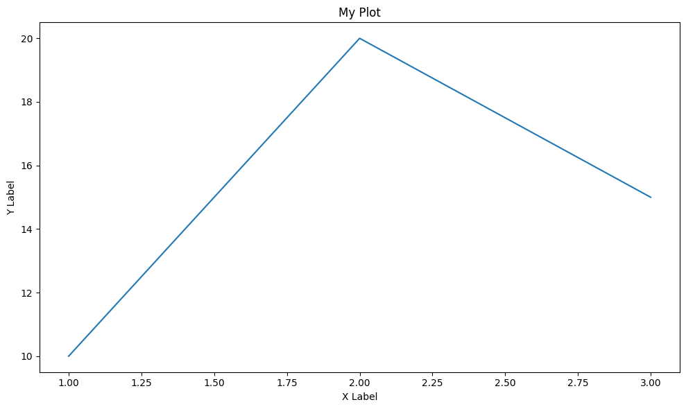

```python
import matplotlib.pyplot as plt
import numpy as np
import pandas as pd

# plt is the standard alias for matplotlib.pyplot

# In Jupyter Notebook or Google Colab, add this line to show plots inline:
# %matplotlib inline

# Figure anatomy:
# Figure  — the entire window/image (can contain multiple plots)
# Axes    — a single plot within the figure
# Axis    — the x-axis or y-axis (lines with tick marks)
# Title   — title of the plot
# Labels  — x-axis label, y-axis label
# Legend  — key explaining each line/bar

# Basic plot structure:
fig, ax = plt.subplots(figsize=(10, 6))   # Create figure and axes
# figsize=(width, height) in inches

ax.plot([1,2,3], [10,20,15])   # Add data
ax.set_title('My Plot')         # Set title
ax.set_xlabel('X Label')        # Set x-axis label
ax.set_ylabel('Y Label')        # Set y-axis label

plt.tight_layout()              # Adjust spacing
plt.savefig('my_plot.png', dpi=300, bbox_inches='tight')  # Save
#300 DPI is commonly used for high-resolution raster figures, but always follow #the target publisher's specifications
plt.show()                      # Display
```

**Line Plot - Drug Concentration-Time Curve**

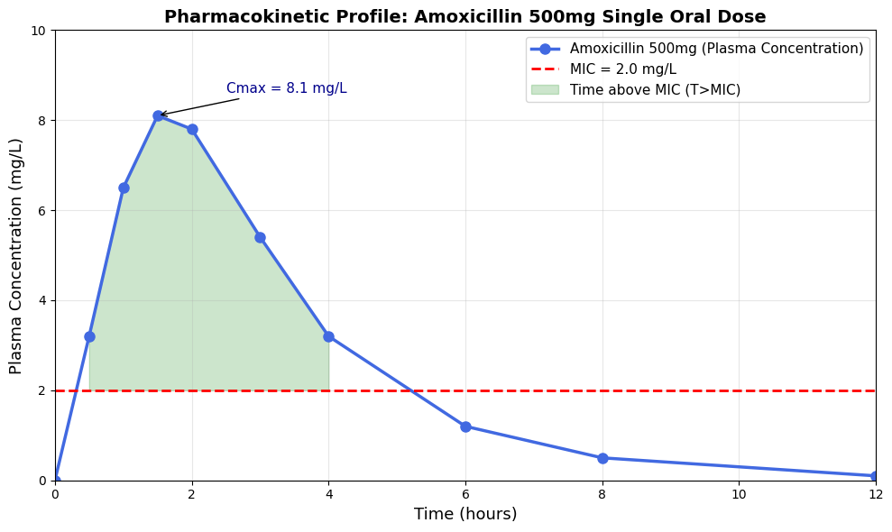

```python
import matplotlib.pyplot as plt
import numpy as np

# Simulated pharmacokinetic data for Amoxicillin 500mg oral dose
# Data based on typical PK parameters (Cmax ~8 mg/L, Tmax ~1.5 hr, t½ ~1.3 hr)

time_hours = np.array([0, 0.5, 1.0, 1.5, 2.0, 3.0, 4.0, 6.0, 8.0, 12.0])
concentration = np.array([0, 3.2, 6.5, 8.1, 7.8, 5.4, 3.2, 1.2, 0.5, 0.1])

# MIC (Minimum Inhibitory Concentration) for common pathogens
mic_value = 2.0  # mg/L

fig, ax = plt.subplots(figsize=(10, 6))

# Main concentration-time curve:
ax.plot(time_hours, concentration,
        color='royalblue',
        linewidth=2.5,
        marker='o',       # Circle markers at data points
        markersize=8,
        label='Amoxicillin 500mg (Plasma Concentration)')

# Horizontal MIC line:
ax.axhline(y=mic_value,
           color='red',
           linestyle='--',
           linewidth=2,
           label=f'MIC = {mic_value} mg/L')

# Shade the area above MIC (“Concentration relative to illustrative MIC”

ax.fill_between(time_hours, concentration, mic_value,
                where=(concentration >= mic_value),
                alpha=0.2,          # Transparency (0=transparent, 1=solid)
                color='green',
                label='Time above MIC (T>MIC)')

# Mark Cmax (peak concentration):
cmax = np.max(concentration)
tmax = time_hours[np.argmax(concentration)]
ax.annotate(
            f'Cmax = {cmax} mg/L',
            xy=(tmax, cmax),
            xytext=(tmax+1, cmax+0.5),
            arrowprops=dict(arrowstyle='->', color='black'),
            fontsize=11, color='darkblue'
)

ax.set_xlabel('Time (hours)', fontsize=13)
ax.set_ylabel('Plasma Concentration (mg/L)', fontsize=13)
ax.set_title('Pharmacokinetic Profile: Amoxicillin 500mg Single Oral Dose',
             fontsize=14, fontweight='bold')
ax.legend(fontsize=11)
ax.grid(True, alpha=0.3)  # Light grid lines
ax.set_xlim(0, 12)
ax.set_ylim(0, 10)

plt.tight_layout()
plt.savefig('amoxicillin_pk_curve.png', dpi=300, bbox_inches='tight')
plt.show()
```

**Histogram - Distribution of Patient Data**

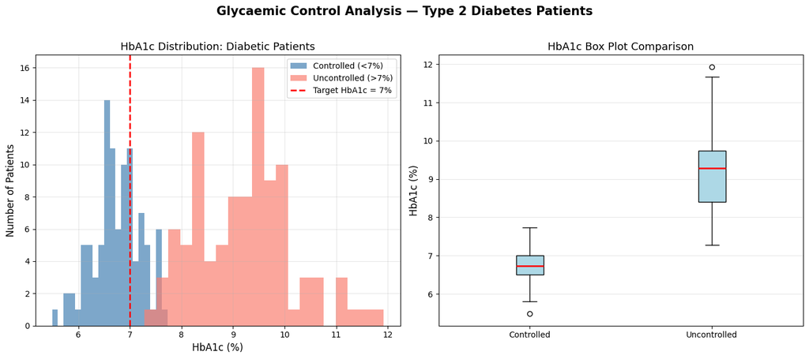

```python
import matplotlib.pyplot as plt
import numpy as np

# Simulate HbA1c values for 200 diabetic patients
# (Real data available from: https://archive.ics.uci.edu/ml/datasets/diabetes)
np.random.seed(42)   # For reproducibility

# HbA1c distribution for controlled vs. uncontrolled diabetes:
controlled   = np.random.normal(loc=6.8, scale=0.5, size=100)   # Well controlled
uncontrolled = np.random.normal(loc=9.2, scale=1.0, size=100)   # Poorly controlled

fig, axes = plt.subplots(1, 2, figsize=(14, 6))  # 1 row, 2 columns

# Plot 1: Both groups overlapping
axes[0].hist(controlled, bins=20, color='steelblue', alpha=0.7, label='Controlled (<7%)')
axes[0].hist(uncontrolled, bins=20, color='salmon', alpha=0.7, label='Uncontrolled (>7%)')

# hist() parameters:
#   bins    : number of bars (default: 10)
#   color   : bar color
#   alpha   : transparency (0 to 1)
#   label   : text for legend
#   density : if True, shows proportion instead of count
#   edgecolor: color of bar borders

axes[0].axvline(x=7.0, color='red', linestyle='--', linewidth=2, label='Target HbA1c = 7%')
axes[0].set_xlabel('HbA1c (%)', fontsize=12)
axes[0].set_ylabel('Number of Patients', fontsize=12)
axes[0].set_title('HbA1c Distribution: Diabetic Patients', fontsize=13)
axes[0].legend(fontsize=10)
axes[0].grid(True, alpha=0.3)

# Plot 2: Box plot for comparison
axes[1].boxplot([controlled, uncontrolled],
                labels=['Controlled', 'Uncontrolled'],
                patch_artist=True,
                boxprops=dict(facecolor='lightblue'),
                medianprops=dict(color='red', linewidth=2))

axes[1].set_ylabel('HbA1c (%)', fontsize=12)
axes[1].set_title('HbA1c Box Plot Comparison', fontsize=13)
axes[1].grid(True, alpha=0.3, axis='y')

plt.suptitle('Glycaemic Control Analysis — Type 2 Diabetes Patients',
             fontsize=15, fontweight='bold', y=1.02)
plt.tight_layout()
plt.savefig('hba1c_analysis.png', dpi=300, bbox_inches='tight')
plt.show()
```

**Box Plot - Comparing Drug Response Across Groups**

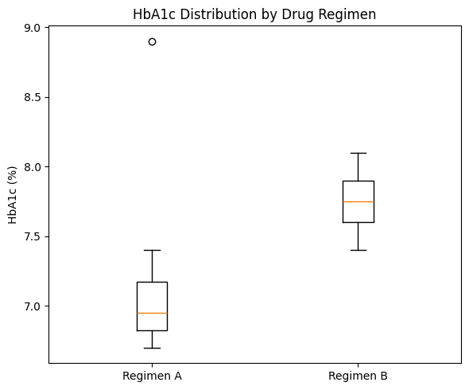

```python
import matplotlib.pyplot as plt

# HbA1c readings (%) for two patient groups on different drug regimens
regimen_a = [6.8, 7.1, 6.9, 7.4, 6.7, 7.0, 8.9, 6.8, 7.2, 6.9]   # 8.9 is an outlier
regimen_b = [7.5, 7.9, 7.6, 8.1, 7.4, 7.8, 7.7, 8.0, 7.6, 7.9]

fig, ax = plt.subplots(figsize=(6, 5))

# One box per group; each box shows median, IQR (25th-75th percentile),
# whiskers, and any outliers as individual points
ax.boxplot([regimen_a, regimen_b], tick_labels=['Regimen A', 'Regimen B'])

ax.set_ylabel('HbA1c (%)')
ax.set_title('HbA1c Distribution by Drug Regimen')
plt.tight_layout()
plt.show()
```

# Bar Chart –(Adverse Drug Reaction)ADR Reporting Visualization

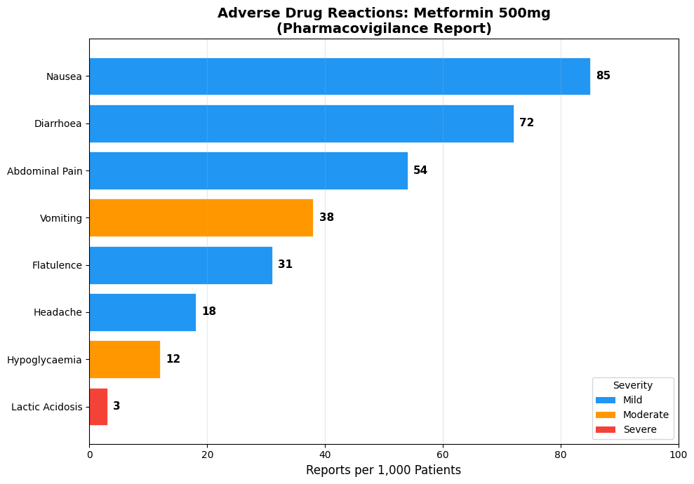

```python
import matplotlib.pyplot as plt
import pandas as pd
import numpy as np

# ADR data for Metformin (based on commonly reported reactions)
#This program uses synthetic/simulated/educational dataset based on the reference # #provided below
# Reference: FDA FAERS database (open source: https://www.fda.gov/drugs/)

adr_data = {
    'Adverse_Reaction': [
        'Nausea', 'Diarrhoea', 'Abdominal Pain', 'Vomiting',
        'Flatulence', 'Headache', 'Lactic Acidosis', 'Hypoglycaemia'
    ],
    'Reports_per_1000': [85, 72, 54, 38, 31, 18, 3, 12],
    'Severity': ['Mild', 'Mild', 'Mild', 'Moderate',
                  'Mild', 'Mild', 'Severe', 'Moderate']
}

df = pd.DataFrame(adr_data)
df = df.sort_values('Reports_per_1000', ascending=True)  # Sort for better visual

# Color by severity:
# Colors are used for readability & visibility perspective & is not a conceptual
# requirement for this course
color_map = {'Mild': '#2196F3', 'Moderate': '#FF9800', 'Severe': '#F44336'}
colors = [color_map[sev] for sev in df['Severity']]

fig, ax = plt.subplots(figsize=(10, 7))

# Horizontal bar chart — better for long labels:
bars = ax.barh(df['Adverse_Reaction'],
               df['Reports_per_1000'],
               color=colors,
               edgecolor='white',
               linewidth=0.5)

# Add value labels on bars:
for bar, value in zip(bars, df['Reports_per_1000']):
    ax.text(bar.get_width() + 1, bar.get_y() + bar.get_height()/2,
            f'{value}', va='center', ha='left', fontsize=11, fontweight='bold')

# Custom legend for severity:
from matplotlib.patches import Patch
legend_elements = [Patch(facecolor=v, label=k) for k, v in color_map.items()]
ax.legend(handles=legend_elements, title='Severity', fontsize=10, loc='lower right')

ax.set_xlabel('Reports per 1,000 Patients', fontsize=12)
ax.set_title('Adverse Drug Reactions: Metformin 500mg\n(Pharmacovigilance Report)',
             fontsize=14, fontweight='bold')
ax.set_xlim(0, 100)
ax.grid(True, axis='x', alpha=0.3)

plt.tight_layout()
plt.savefig('metformin_adr_chart.png', dpi=300, bbox_inches='tight')
plt.show()
```

# Scatter Plot - Dose-Response Relationship

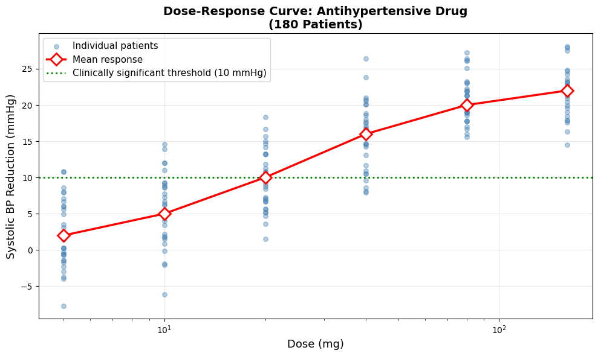

```python
import matplotlib.pyplot as plt
import numpy as np

# Simulated dose-response data for an antihypertensive drug
np.random.seed(123)

doses = [5, 10, 20, 40, 80, 160]   # mg
mean_sbp_reduction = [2, 5, 10, 16, 20, 22]   # mmHg systolic BP reduction

# Simulate individual patient responses (scatter around mean):
all_doses, all_responses = [], []
for dose, mean_resp in zip(doses, mean_sbp_reduction):
    n_patients = 30
    individual_responses = np.random.normal(mean_resp, 4, n_patients)
    all_doses.extend([dose] * n_patients)
    all_responses.extend(individual_responses)

fig, ax = plt.subplots(figsize=(10, 6))

# Scatter plot of individual patients:
scatter = ax.scatter(all_doses, all_responses,
                     alpha=0.4,           # Transparency to see overlapping points
                     color='steelblue',
                     s=30,                # Point size
                     label='Individual patients',
                     zorder=2)            # Draw on top

# Mean response line:
ax.plot(doses, mean_sbp_reduction,
        color='red', linewidth=2.5,
        marker='D', markersize=10,
        markerfacecolor='white', markeredgecolor='red', markeredgewidth=2,
        label='Mean response', zorder=3)

# Reference line: clinically meaningful reduction (≥10 mmHg):
ax.axhline(y=10, color='green', linestyle=':', linewidth=2,
           label='Clinically significant threshold (10 mmHg)')

ax.set_xlabel('Dose (mg)', fontsize=13)
ax.set_ylabel('Systolic BP Reduction (mmHg)', fontsize=13)
ax.set_title('Dose-Response Curve: Antihypertensive Drug\n(180 Patients)',
             fontsize=14, fontweight='bold')
ax.legend(fontsize=11)
ax.grid(True, alpha=0.3)
ax.set_xscale('log')   # Log scale for doses — common in pharmacology

plt.tight_layout()
plt.savefig('dose_response_scatter.png', dpi=300, bbox_inches='tight')
plt.show()
```

```python
clinical_loc='Delhi-007'
print(clinical_loc)
```

```
Delhi-007
```

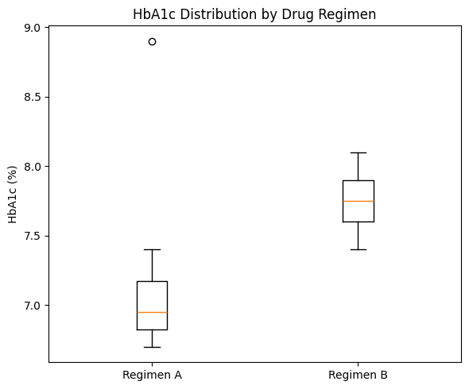

```python
import matplotlib.pyplot as plt

# HbA1c readings (%) for two patient groups on different drug regimens
regimen_a = [6.8, 7.1, 6.9, 7.4, 6.7, 7.0, 8.9, 6.8, 7.2, 6.9]   # 8.9 is an outlier
regimen_b = [7.5, 7.9, 7.6, 8.1, 7.4, 7.8, 7.7, 8.0, 7.6, 7.9]

fig, ax = plt.subplots(figsize=(6, 5))

# One box per group; each box shows median, IQR (25th-75th percentile),
# whiskers, and any outliers as individual points
ax.boxplot([regimen_a, regimen_b], tick_labels=['Regimen A', 'Regimen B'])

ax.set_ylabel('HbA1c (%)')
ax.set_title('HbA1c Distribution by Drug Regimen')
plt.tight_layout()
plt.show()
```

**Sample code to get data from FDA by making HTTP requests**

```python
import requests    # For making HTTP requests
import pandas as pd
import json

# OpenFDA API — Free, no registration needed for basic use
# Documentation: https://open.fda.gov/apis/

# Example: Get adverse events for Metformin
url = 'https://api.fda.gov/drug/event.json'
params = {
    'search': 'patient.drug.medicinalproduct:metformin',
    'count': 'patient.reaction.reactionmeddrapt.exact',
    'limit': 10
}

response = requests.get(url, params=params)

if response.status_code == 200:
    data = response.json()
    results = data['results']

    # Convert to DataFrame:
    df = pd.DataFrame(results)
    df.columns = ['Adverse_Reaction', 'Report_Count']
    df = df.sort_values('Report_Count', ascending=False)

    print('Top 10 Adverse Reactions for Metformin (FDA FAERS):')
    print(df.to_string(index=False))
else:
    print(f'Error: {response.status_code}')
```

```
Top 10 Adverse Reactions for Metformin (FDA FAERS):
       Adverse_Reaction  Report_Count
                 NAUSEA         30197
              DIARRHOEA         28015
BLOOD GLUCOSE INCREASED         27175
       DRUG INEFFECTIVE         22503
                FATIGUE         21324
        LACTIC ACIDOSIS         20130
               VOMITING         19625
    ACUTE KIDNEY INJURY         18364
       WEIGHT DECREASED         17304
               DYSPNOEA         16777
```

Sample code that fetches the top adverse reactions reported for a given drug from the FDA's openFDA Drug Adverse Event API and returns them as a pandas DataFrame.

```python
"""
FAERS Adverse Event Lookup (openFDA API)
------------------------------------------
Fetches the top adverse reactions reported for a given drug from the
FDA's openFDA Drug Adverse Event API and returns them as a pandas DataFrame.

Documentation: https://open.fda.gov/apis/

Enhancements over the original script:
  1. Input validation & sanitization for the drug name
  2. Explicit request timeout (prevents the script hanging forever)
  3. Retry logic with exponential backoff for transient network/server errors
  4. Granular exception handling (connection, timeout, HTTP, JSON, schema)
  5. HTTPS enforced; response size capped to avoid memory-exhaustion issues
  6. Optional API key read from an environment variable (never hardcoded)
  7. Logging instead of bare print() for real diagnostics
  8. No use of eval/exec/str-formatted SQL/etc. — all params passed via
     `requests`' own `params=` dict, which handles URL-encoding for you
     and avoids manual string concatenation into the URL (a common
     injection vector when people build query strings by hand).
"""

import logging
import os
import re
import time
from dataclasses import dataclass
from typing import Optional

import pandas as pd
import requests
from requests.adapters import HTTPAdapter
from urllib3.util.retry import Retry

# --------------------------------------------------------------------------
# Configuration
# --------------------------------------------------------------------------

FAERS_URL = "https://api.fda.gov/drug/event.json"  # always HTTPS
REQUEST_TIMEOUT_SECONDS = 10          # (connect timeout, read timeout)
MAX_RETRIES = 3
BACKOFF_FACTOR = 1.5                  # 0s, 1.5s, 3s... between retries
MAX_LIMIT = 100                       # openFDA's practical per-request cap
MAX_RESPONSE_BYTES = 5_000_000        # 5 MB safety cap on response size

# openFDA works fine without a key for light use, but an optional key
# raises your rate limit. NEVER hardcode a real key in source code —
# read it from the environment (or a secrets manager) instead.
API_KEY = os.environ.get("OPENFDA_API_KEY")  # None if not set

# Only allow letters, numbers, spaces, and a few safe punctuation marks
# in a drug name. This isn't "SQL injection" territory since `requests`
# URL-encodes params for us, but validating input still protects you
# against malformed/oversized queries and unexpected API errors.
_DRUG_NAME_PATTERN = re.compile(r"^[A-Za-z0-9 \-']{1,100}$")

logging.basicConfig(
    level=logging.INFO,
    format="%(asctime)s [%(levelname)s] %(message)s",
)
logger = logging.getLogger("faers_lookup")


# --------------------------------------------------------------------------
# Custom exceptions — lets callers distinguish failure types cleanly
# --------------------------------------------------------------------------

class FAERSLookupError(Exception):
    """Base class for all errors raised by this module."""


class InvalidDrugNameError(FAERSLookupError):
    """Raised when the supplied drug name fails validation."""


class FAERSAPIError(FAERSLookupError):
    """Raised when the openFDA API returns an error or malformed response."""


@dataclass
class AdverseEventResult:
    drug_name: str
    dataframe: pd.DataFrame
    total_reports_returned: int


# --------------------------------------------------------------------------
# Core logic
# --------------------------------------------------------------------------

def _validate_drug_name(drug_name: str) -> str:
    """Validate and normalize a user-supplied drug name.

    Raises InvalidDrugNameError if the name looks unsafe or malformed.
    """
    if not isinstance(drug_name, str):
        raise InvalidDrugNameError("Drug name must be a string.")

    cleaned = drug_name.strip()

    if not cleaned:
        raise InvalidDrugNameError("Drug name cannot be empty.")

    if not _DRUG_NAME_PATTERN.match(cleaned):
        raise InvalidDrugNameError(
            f"Drug name '{drug_name}' contains unsupported characters. "
            "Only letters, numbers, spaces, hyphens, and apostrophes are allowed."
        )

    return cleaned.lower()


def _build_session() -> requests.Session:
    """Create a requests Session configured with automatic retries.

    Retries only on transient failures (connection errors, 5xx server
    errors, and 429 rate-limit responses) — never on 4xx client errors
    like a bad request, since retrying those won't help.
    """
    session = requests.Session()
    retry_strategy = Retry(
        total=MAX_RETRIES,
        backoff_factor=BACKOFF_FACTOR,
        status_forcelist=[429, 500, 502, 503, 504],
        allowed_methods=["GET"],
        raise_on_status=False,
    )
    adapter = HTTPAdapter(max_retries=retry_strategy)
    session.mount("https://", adapter)
    # Deliberately do NOT mount a plain "http://" adapter — this ensures
    # any accidental non-HTTPS URL fails fast instead of sending data
    # in the clear.
    session.headers.update({
        "User-Agent": "Pocket-Python-Pharma-Textbook/1.0 (educational use)",
        "Accept": "application/json",
    })
    return session


def fetch_adverse_events(
    drug_name: str,
    limit: int = 10,
    session: Optional[requests.Session] = None,
) -> AdverseEventResult:
    """Fetch the top reported adverse reactions for a drug from FAERS.

    Parameters
    ----------
    drug_name : str
        Name of the drug to search for (e.g. "metformin").
    limit : int
        Number of top adverse-reaction categories to return (1-100).
    session : requests.Session, optional
        Reuse an existing session (e.g. across multiple lookups) instead
        of creating a new one each call.

    Returns
    -------
    AdverseEventResult
        Structured result containing the drug name, a DataFrame of
        (Adverse_Reaction, Report_Count), and the row count returned.

    Raises
    ------
    InvalidDrugNameError
        If drug_name or limit fails validation.
    FAERSAPIError
        If the API call fails, times out, or returns malformed data.
    """
    validated_name = _validate_drug_name(drug_name)

    if not isinstance(limit, int) or not (1 <= limit <= MAX_LIMIT):
        raise InvalidDrugNameError(
            f"'limit' must be an integer between 1 and {MAX_LIMIT}."
        )

    params = {
        "search": f"patient.drug.medicinalproduct:{validated_name}",
        "count": "patient.reaction.reactionmeddrapt.exact",
        "limit": limit,
    }
    if API_KEY:
        params["api_key"] = API_KEY

    owns_session = session is None
    session = session or _build_session()

    try:
        logger.info("Requesting FAERS adverse-event data for '%s'...", validated_name)
        response = session.get(
            FAERS_URL,
            params=params,
            timeout=REQUEST_TIMEOUT_SECONDS,
        )

        # Guard against an unexpectedly huge payload before parsing it.
        content_length = response.headers.get("Content-Length")
        if content_length and int(content_length) > MAX_RESPONSE_BYTES:
            raise FAERSAPIError(
                f"Response too large ({content_length} bytes) — refusing to parse."
            )

        # openFDA returns 404 (not an error status per se) when a search
        # matches zero records — handle that distinctly from real failures.
        if response.status_code == 404:
            logger.warning("No FAERS records found for '%s'.", validated_name)
            return AdverseEventResult(
                drug_name=validated_name,
                dataframe=pd.DataFrame(columns=["Adverse_Reaction", "Report_Count"]),
                total_reports_returned=0,
            )

        response.raise_for_status()  # raises HTTPError for 4xx/5xx (except 404, handled above)

        try:
            data = response.json()
        except ValueError as exc:
            raise FAERSAPIError("openFDA response was not valid JSON.") from exc

        results = data.get("results")
        if results is None:
            raise FAERSAPIError("Unexpected API response: missing 'results' field.")

        df = pd.DataFrame(results)
        if df.empty:
            df = pd.DataFrame(columns=["Adverse_Reaction", "Report_Count"])
        else:
            # Defensive rename: only proceed if the expected columns are present,
            # rather than blindly assuming column order/count as the original did.
            expected_cols = {"term", "count"}
            if not expected_cols.issubset(df.columns):
                raise FAERSAPIError(
                    f"Unexpected result schema. Got columns: {list(df.columns)}"
                )
            df = df.rename(columns={"term": "Adverse_Reaction", "count": "Report_Count"})
            df = df.sort_values("Report_Count", ascending=False).reset_index(drop=True)

        logger.info(
            "Retrieved %d adverse-reaction categories for '%s'.",
            len(df), validated_name,
        )
        return AdverseEventResult(
            drug_name=validated_name,
            dataframe=df,
            total_reports_returned=len(df),
        )

    except requests.exceptions.Timeout as exc:
        raise FAERSAPIError(
            f"Request to openFDA timed out after {REQUEST_TIMEOUT_SECONDS}s."
        ) from exc
    except requests.exceptions.ConnectionError as exc:
        raise FAERSAPIError(
            "Could not connect to openFDA. Check your network connection."
        ) from exc
    except requests.exceptions.HTTPError as exc:
        status = exc.response.status_code if exc.response is not None else "unknown"
        raise FAERSAPIError(f"openFDA returned an HTTP error (status {status}).") from exc
    except requests.exceptions.RequestException as exc:
        # Catch-all for any other requests-library failure we didn't
        # anticipate, so callers never see a raw, unfiltered exception type.
        raise FAERSAPIError(f"Unexpected request failure: {exc}") from exc
    finally:
        if owns_session:
            session.close()


# --------------------------------------------------------------------------
# Script entry point
# --------------------------------------------------------------------------

def main() -> None:
    drug_name = "metformin"

    try:
        result = fetch_adverse_events(drug_name, limit=10)
    except InvalidDrugNameError as exc:
        logger.error("Invalid input: %s", exc)
        return
    except FAERSAPIError as exc:
        logger.error("Lookup failed: %s", exc)
        return

    if result.total_reports_returned == 0:
        print(f"No adverse event data found for '{result.drug_name}'.")
        return

    print(f"\nTop {result.total_reports_returned} Adverse Reactions for "
          f"{result.drug_name.title()} (FDA FAERS):")
    print(result.dataframe.to_string(index=False))


if __name__ == "__main__":
    main()
```

```
Top 10 Adverse Reactions for Metformin (FDA FAERS):
       Adverse_Reaction  Report_Count
                 NAUSEA         30197
              DIARRHOEA         28015
BLOOD GLUCOSE INCREASED         27175
       DRUG INEFFECTIVE         22503
                FATIGUE         21324
        LACTIC ACIDOSIS         20130
               VOMITING         19625
    ACUTE KIDNEY INJURY         18364
       WEIGHT DECREASED         17304
               DYSPNOEA         16777
```

# Final Mini Project

**Problem Context** A regional pharmacy network runs periodic diabetes screening events at its retail locations. Each event produces a spreadsheet export of patient measurements (glucose, BMI, blood pressure, age, and related fields) alongside a screening outcome. Leadership has asked the analytics team to turn this raw export into a short report that pharmacists can use to identify which patients are at elevated risk and deserve priority outreach — before any of that data is used for real clinical decisions.

For this exercise, you will use a public dataset that mirrors exactly this kind of screening export, and work through the same pipeline a real analytics team would: load it, question it, clean it, analyze it, visualize it, and summarize it in plain language. Dataset Pima Indians Diabetes Database (public, UCI Machine Learning Repository) 768 female patients · 8 clinical measurements · 1 outcome label (0 = non-diabetic, 1 = diabetic) Source: raw.githubusercontent.com/jbrownlee/Datasets/master/pima-indians-diabetes.data.csv

Tools Required pandas Loading, cleaning, grouping, and summarizing the patient dataset NumPy Numerical calculations, conditional flags, and correlation analysis Matplotlib Charts to visualize distributions, comparisons, and risk trends

Sequence of Tasks

1. Load the data. Read the CSV into a pandas DataFrame. Since the file has no header row, supply column names yourself. Confirm the shape (rows × columns) matches what you expect.
2. Explore before touching anything. Use .head(), .info(), .dtypes, and .describe() to understand what you're working with — data types, ranges, and obvious oddities — before making any changes.
3. Audit for data quality issues. Several columns use 0 as a placeholder for a missing reading (a real patient can't have a BMI or blood pressure of exactly 0). Count how many zeros appear in each affected column and what percentage of patients that represents.
4. Clean the dataset. Replace the invalid zeros with NaN, then fill each column's missing values using that column's median (more robust to outliers than the mean). Document how many values were filled per column.
5. Engineer a risk feature. Using NumPy's np.where(), create a new BMI_Category column (Underweight / Normal / Overweight / Obese) from the raw BMI value.
6. Run group comparisons. Use pandas .groupby() to compare average Glucose, BMI, Age, and Blood Pressure between diabetic and non-diabetic patients, and to calculate the diabetes rate within each BMI category.
7. Check correlations. Identify which measured variable has the strongest observed association with the diabetes outcome in this dataset.
8. Flag a high-risk segment. Combine at least two conditions (e.g. Glucose above a threshold AND BMI above a threshold) with pandas Boolean indexing to isolate a priority-outreach patient segment. Report how large this segment is and its diabetes rate compared to everyone else.
9. Visualize the findings. Produce at least three charts with Matplotlib: a histogram of a key measurement, a bar chart comparing diabetes rate across BMI categories, and a scatter plot of two related measurements. Every chart needs a title and labeled axes.
10. Export and summarize. Save the cleaned, annotated dataset as a new CSV file, then write a short plain-language summary (5–6 sentences) stating the overall diabetes rate, the strongest risk factor, and who the priority-outreach segment is — written for a pharmacist, not a programmer.

Deliverables DELIVERABLE WHAT IT SHOULD CONTAIN Cleaned dataset A CSV file with missing/invalid values properly handled and documented Risk segmentation table Patients grouped into clear risk categories with counts and rates per group Chart set (3–4 visuals) Distribution, comparison, and relationship charts, each with titles and labeled axes One-page summary Plain-language key findings a pharmacist could act on without reading the code

## Final Mini Project: Pima Indians Diabetes Data Analysis

### Task 1: Load the Data

```python
import pandas as pd
import numpy as np
import matplotlib.pyplot as plt
import seaborn as sns
import urllib.request
import os

# Source URL for the dataset
DATA_URL = "https://raw.githubusercontent.com/jbrownlee/Datasets/master/pima-indians-diabetes.data.csv"
LOCAL_FILE = "pima-indians-diabetes.csv"

# Download the dataset if it doesn't already exist locally
if not os.path.exists(LOCAL_FILE):
    print(f"Downloading dataset from {DATA_URL}...")
    urllib.request.urlretrieve(DATA_URL, LOCAL_FILE)
    print("Download complete.")
else:
    print(f"Using already-downloaded file: {LOCAL_FILE}")


# Define column names as the dataset has no header
column_names = [
    "Pregnancies",              # Number of times pregnant
    "Glucose",                  # Plasma glucose concentration a 2 hours in an oral glucose tolerance test
    "BloodPressure",            # Diastolic blood pressure (mm Hg)
    "SkinThickness",            # Triceps skin fold thickness (mm)
    "Insulin",                  # 2-Hour serum insulin (mu U/ml)
    "BMI",                      # Body mass index (weight in kg/(height in m)^2)
    "DiabetesPedigreeFunction", # Diabetes pedigree function
    "Age",                      # Age (years)
    "Outcome"                   # Class variable (0 = non-diabetic, 1 = diabetic)
]

# Load the CSV into a pandas DataFrame
df = pd.read_csv(LOCAL_FILE, names=column_names)

# Confirm the shape of the DataFrame
print(f"\nDataset loaded. Shape: {df.shape} (rows, columns)")

# Display the first 5 rows to verify loading and column names
print("\nFirst 5 rows of the dataset:")
display(df.head())
```

```
Downloading dataset from https://raw.githubusercontent.com/jbrownlee/Datasets/master/pima-indians-diabetes.data.csv...
Download complete.

Dataset loaded. Shape: (768, 9) (rows, columns)

First 5 rows of the dataset:
```

|  | Pregnancies | Glucose | BloodPressure | SkinThickness | Insulin | BMI | DiabetesPedigreeFunction | Age | Outcome |
| --- | --- | --- | --- | --- | --- | --- | --- | --- | --- |
| 0 | 6 | 148 | 72 | 35 | 0 | 33.6 | 0.627 | 50 | 1 |
| 1 | 1 | 85 | 66 | 29 | 0 | 26.6 | 0.351 | 31 | 0 |
| 2 | 8 | 183 | 64 | 0 | 0 | 23.3 | 0.672 | 32 | 1 |
| 3 | 1 | 89 | 66 | 23 | 94 | 28.1 | 0.167 | 21 | 0 |
| 4 | 0 | 137 | 40 | 35 | 168 | 43.1 | 2.288 | 33 | 1 |